# Ein 3D-CNN trainieren und seine Entscheidungen erklären

**Ein Einstieg in Deep Learning und Explainable AI (XAI) am Spielzeug-Beispiel**

## Worum geht es in diesem Notebook?

Neuronale Netze sind hervorragende Mustererkenner, aber sie sind zunächst *Blackboxes*: Wir sehen die Vorhersage, nicht aber die Begründung. In sicherheitskritischen Anwendungen — allen voran der medizinischen Bildgebung — ist das ein Problem. Ein Netz, das Krankheiten auf MRT-Aufnahmen erkennt, mag 95 % Genauigkeit erreichen und trotzdem völlig unbrauchbar sein, weil es heimlich auf ein Artefakt des Scanners oder eine Textmarkierung im Bildrand achtet statt auf die Pathologie. Diesen Effekt nennt man *Clever-Hans-Verhalten* (Lapuschkin et al., 2019): Das Modell gibt die richtige Antwort aus dem falschen Grund.

Das Forschungsfeld, das solche Begründungen sichtbar macht, heißt **Explainable AI (XAI)**. Dieses Notebook demonstriert eine der etablierten XAI-Methoden — **Layer-wise Relevance Propagation (LRP)** — in einem absichtlich winzigen, vollständig kontrollierten Szenario:

1. Wir **erzeugen** einen synthetischen 3D-Datensatz aus drei Klassen (Würfel, Kugel, Rauschen). Weil wir die Daten selbst gebaut haben, wissen wir *genau*, welche Bildbereiche relevant sein *sollten*.
2. Wir **trainieren** ein kleines 3D-Convolutional-Neural-Network (CNN) darauf.
3. Wir **erklären** die Vorhersagen mit LRP und prüfen, ob die Erklärungen mit unserer Erwartung übereinstimmen.
4. Wir stellen dem Modell **Hybrid-Objekte** vor (halb Würfel, halb Kugel), die es im Training nie gesehen hat, und beobachten, wie sich die Erklärungen verändern.

## Warum ein Spielzeug-Datensatz?

Das mag akademisch wirken, ist aber methodisch zentral. Für echte medizinische Bilder gibt es keine *Ground Truth für Erklärungen*: Niemand kann sagen, welches Voxel eine korrekte Erklärung hervorheben müsste. Bei einem Würfel, den wir selbst in ein leeres Volumen gezeichnet haben, wissen wir es. Synthetische Daten sind deshalb der Prüfstand, auf dem man eine XAI-Methode *validiert*, bevor man ihr auf echten Daten glaubt. Genau diese Rolle hat dieses Notebook im Repository: Es ist die Sanity-Check-Stufe vor den Notebooks zu MRT-Hirnalter-Vorhersage und VGG-Bildklassifikation.

## Voraussetzungen

Grundkenntnisse in Python und NumPy. Deep-Learning-Vorwissen ist nicht nötig — die Konzepte (Convolution, Pooling, Softmax, Cross-Entropy) werden an der Stelle erklärt, an der sie zum ersten Mal auftauchen.

## Inhaltsverzeichnis

| Abschnitt | Thema |
| --- | --- |
| 1. Setup und Reproduzierbarkeit | Pfade, Imports, Zufallssaat |
| 2. Den synthetischen 3D-Datensatz erzeugen | Würfel, Kugeln und Rauschen in Voxelgittern |
| 2.1 Interpretation: Übersicht über die Stichproben | Was die Schnittbilder zeigen |
| 2.2 Vorverarbeitung: One-Hot-Kodierung und Datensplit | Labels als Vektoren, Trainings-/Testmenge |
| 3. Das 3D-CNN aufbauen und trainieren | Faltung, Normalisierung, Pooling, Klassifikation |
| 3.1 Interpretation: Was beim Training passiert ist | Modell laden statt neu trainieren |
| 4. Die Schichten des Modells zählen | Warum diese Zahl für LRP wichtig ist |
| 5. Layer-wise Relevance Propagation (LRP) | Die Theorie hinter den Heatmaps |
| 5.1 Die LRP-Strategie dieses Notebooks | Welche Regel auf welche Schicht wirkt |
| 6. Die Reihenfolge der Klassen | Eine kleine, aber fehleranfällige Stelle |
| 7. Erklärungen für echte Stichproben | Ein Erklärungsbild pro Klasse |
| 7.1 Interpretation: Die Heatmaps der Stichproben | Randartefakte, Rauschen, Signal |
| 8. Das Gegenprobe-Experiment: Hybrid-Objekte | Halb Würfel, halb Kugel |
| 8.1 Interpretation: Vorhersagen und Erklärungen der Hybride | Der Würfel-Bias des Modells |
| 9. Alles in einer Abbildung | Dieselbe Analyse als speicherbare Gesamtgrafik |
| 9.1 Interpretation: Die Gesamtabbildung | Muster über alle sechs Hybride |
| 10. Interaktive 3D-Darstellung | Von Schnittbildern zur Punktwolke |
| 11. Fazit und weiterführende Schritte | Was wir gelernt haben, was zu verbessern wäre |

# 1. Setup und Reproduzierbarkeit

↑ Inhaltsverzeichnis

## Was diese Zelle berechnet

Diese Zelle rechnet noch nichts Inhaltliches, sondern richtet die Arbeitsumgebung ein. Vier Dinge passieren:

**1. Das Repository-Wurzelverzeichnis finden.** `find_repo_root()` läuft vom aktuellen Arbeitsverzeichnis aus schrittweise nach oben (`p.parents`), bis es einen Ordner findet, der eine `pyproject.toml` oder einen `explainability/`-Ordner enthält. Dieser Pfad wird dann an `sys.path` gehängt. Ohne diesen Schritt könnte Python die lokale Bibliothek `explainability` (die LRP-Implementierung dieses Repos) nicht importieren, denn Notebooks starten je nach Umgebung in unterschiedlichen Verzeichnissen. Das ist ein typisches Muster in Forschungscode und macht das Notebook unabhängig davon, von wo aus es gestartet wird.

**2. Bibliotheken importieren.** `numpy` für Zahlen-Arrays, `matplotlib` für Grafiken, aus `scikit-learn` die Funktion `euclidean_distances` (zum Zeichnen der Kugeln) und `OneHotEncoder` (zur Label-Kodierung).

**3. Einen Ausgabeordner anlegen.** `find_notebook_name()` ermittelt den Namen des laufenden Notebooks — bewusst ohne fest verdrahteten Namen, damit ein Umbenennen des Notebooks automatisch auch den Ausgabeordner umbenennt. Nötig sind dafür mehrere Quellen, weil keine einzelne in allen Umgebungen funktioniert: `ipynbname.name()` fragt den Jupyter-Server und deckt den interaktiven Fall (JupyterLab, VS Code) ab, scheitert aber unter `nbconvert`, weil dort kein Server läuft. Dann greifen der Reihe nach die Kernel-Umgebungsvariable `JPY_SESSION_NAME`, `__file__` (falls die `.py`-Fassung direkt als Skript läuft) und schließlich die Kommandozeile des aufrufenden Prozesses, in der `nbconvert` bzw. Quarto den Notebook-Pfad stehen hat. Findet keine Quelle etwas, bricht die Zelle mit einer Fehlermeldung ab, statt stillschweigend in einen falschen Ordner zu schreiben; mit der Umgebungsvariablen `NOTEBOOK_NAME` kann man den Namen im Notfall vorgeben. Alle Grafiken und das trainierte Modell landen anschließend unter `output/notebooks/<Notebook-Name>/`.

**4. Die Zufallssaat setzen.** `np.random.seed(42)` ist der wichtigste Aufruf dieser Zelle. Der Datensatz wird gleich zufällig generiert; ohne feste Saat bekäme man bei jedem Ausführen andere Würfel und Kugeln, und alle Ergebnisse wären nicht mehr vergleichbar. **Reproduzierbarkeit** ist in der Machine-Learning-Forschung keine Kür, sondern Pflicht — ein Ergebnis, das man nicht wiederherstellen kann, ist kein Ergebnis.

> **Hinweis:** Eine feste NumPy-Saat macht die *Datengenerierung* deterministisch, nicht aber das gesamte Training. TensorFlow hat einen eigenen Zufallsgenerator (Gewichtsinitialisierung, Dropout, Batch-Reihenfolge), und GPU-Kernel liefern nicht immer bit-identische Ergebnisse. Für volle Determinismus bräuchte man zusätzlich `tf.keras.utils.set_random_seed()` und `tf.config.experimental.enable_op_determinism()`.

```python
import os
import sys
from pathlib import Path


def find_repo_root() -> Path:
    p = Path.cwd().resolve()
    for candidate in [p, *p.parents]:
        if (candidate / "pyproject.toml").exists() or (candidate / "explainability").is_dir():
            return candidate
    return p


repo_root = find_repo_root()
if str(repo_root) not in sys.path:
    sys.path.insert(0, str(repo_root))

import matplotlib.pyplot as plt
import numpy as np

from sklearn.metrics.pairwise import euclidean_distances
from sklearn.preprocessing import OneHotEncoder
from typing import Tuple

import ipynbname


def _process_ancestors(pid: int, levels: int = 5) -> list[int]:
    pids = []
    for _ in range(levels):
        pids.append(pid)
        try:
            stat = Path(f"/proc/{pid}/stat").read_text()
            # Feld 4 von stat ist die PPID; der Prozessname in Feld 2 kann
            # Leerzeichen enthalten, deshalb erst hinter ")" trennen
            pid = int(stat[stat.rindex(")") + 1:].split()[1])
        except Exception:
            break
        if pid <= 1:
            break
    return pids


def find_notebook_name() -> str:
    """Ermittelt den Namen des laufenden Notebooks ohne .ipynb-Endung."""
    # 1. Interaktiv (JupyterLab, VS Code): ipynbname fragt den Jupyter-Server
    #    bzw. liest __vsc_ipynb_file__
    try:
        return ipynbname.name()
    except Exception:
        pass

    # 2. jupyter-server >= 2 stellt den Notebook-Pfad in die Kernel-Umgebung,
    #    papermill & Co. setzen __session__
    for candidate in (os.environ.get("JPY_SESSION_NAME"), globals().get("__session__")):
        if candidate and candidate.endswith(".ipynb"):
            return Path(candidate).stem

    # 3. Als reines Skript ausgeführt (python notebooks/py_files/<name>.py)
    if "__file__" in globals():
        return Path(globals()["__file__"]).stem

    # 4. Unter nbconvert/quarto gibt es keine der obigen Quellen — dort steht der
    #    Notebook-Pfad aber in der Kommandozeile des aufrufenden Prozesses
    #    (JPY_PARENT_PID zeigt auf nbconvert, dessen Vorfahren auf make/quarto)
    start_pid = int(os.environ.get("JPY_PARENT_PID") or os.getppid())
    for pid in _process_ancestors(start_pid):
        try:
            args = Path(f"/proc/{pid}/cmdline").read_bytes().decode().split("\0")
        except Exception:
            continue
        for arg in args:
            if arg.endswith(".ipynb"):
                return Path(arg).stem

    raise RuntimeError(
        "Notebook-Name konnte nicht ermittelt werden — bitte NOTEBOOK_NAME setzen."
    )


# 2. Notebook-Namen aus der Laufzeitumgebung ermitteln
notebook_name = os.environ.get("NOTEBOOK_NAME") or find_notebook_name()

# 3. Pfad zusammensetzen: (root-dir-des-repos) / output/notebooks / notebook_name
target_dir = repo_root / "output/notebooks" / notebook_name

# 4. Ordner erstellen
target_dir.mkdir(parents=True, exist_ok=True)

print(f"Notebook-Name ist: {notebook_name}")
print(f"Zielordner ist: {target_dir}")

# für wiederholung
np.random.seed(42)
```

```
Notebook-Name ist: Train_and_explain_dummy_geometric_data
Zielordner ist: /mnt/users/andreasre/git-repos/keras-explainability/output/notebooks/Train_and_explain_dummy_geometric_data
```

# 2. Den synthetischen 3D-Datensatz erzeugen

↑ Inhaltsverzeichnis

## Der größere Kontext: Was ist ein 3D-Bild?

Ein gewöhnliches Graustufenbild ist eine Matrix aus **Pixeln** — eine zweidimensionale Anordnung von Helligkeitswerten. Medizinische Bildgebung wie MRT oder CT liefert stattdessen **Volumendaten**: ein dreidimensionales Gitter aus **Voxeln** (*volumetric pixels*). Jedes Voxel hat eine Position $(i, j, k)$ und einen Intensitätswert.

In diesem Notebook arbeiten wir mit Volumen der Größe $16 \times 16 \times 16 = 4096$ Voxeln. Das ist winzig — ein echtes MRT hat leicht $256^3 \approx 16.8$ Millionen Voxel — aber es genügt vollkommen, um die Prinzipien zu zeigen, und es läuft auch ohne GPU in Sekunden.

## Was diese Zelle berechnet

Drei Generatorfunktionen erzeugen je eine Klasse von Volumen:

**`generate_circle`** — zeichnet eine **Kugel** (auch hier ist der Name zweidimensional gedacht). Ein zufälliges Zentrum $z \sim \mathcal{U}\{0,\dots,15\}^3$ und ein zufälliger Radius $r \sim \mathcal{U}\{4,\dots,7\}$ werden gezogen, dann wird für *jedes* Voxel $p$ des Gitters die euklidische Distanz

$$d(p, z) = \sqrt{(p_1-z_1)^2 + (p_2-z_2)^2 + (p_3-z_3)^2}$$

berechnet und das Voxel gesetzt, falls $d(p,z) \le r$. Weil das Zentrum überall liegen darf — auch direkt am Rand — sind viele Kugeln nur als Segment sichtbar.

**`generate_noise`** — zieht jedes Voxel unabhängig aus einer stetigen Gleichverteilung, $v \sim \mathcal{U}(0,1)$. Diese Klasse ist der **Negativ-Fall**: Sie hat keine geometrische Struktur, nur Textur.

Anschließend werden $n = 200$ Volumen pro Klasse erzeugt, zu einem Array $X$ mit 600 Elementen zusammengefügt, die Labels $y$ als Strings angelegt und beides mit derselben Permutation `idx` **gemeinsam durchmischt**. Das gleichzeitige Mischen von $X$ und $y$ ist essenziell — würde man nur eines von beiden mischen, wären alle Labels falsch zugeordnet.

`X` wird auf die Form `(600, 16, 16, 16, 1)` umgeformt. Diese fünf Dimensionen bedeuten `(Stichproben, Tiefe, Höhe, Breite, Kanäle)`. Die letzte 1 ist der **Kanal**: Bei Farbbildern stünde hier 3 (Rot, Grün, Blau), bei uns gibt es nur einen Intensitätskanal. Keras erwartet diese Dimension immer, auch wenn sie die Länge 1 hat.

## Ein wichtiger Unterschied zwischen den Klassen

Beachten Sie die Wertebereiche: Würfel und Kugeln sind **binär** (0 oder 1), Rauschen ist **kontinuierlich** (jeder Wert in $[0,1)$). Der mittlere Voxelwert unterscheidet sich damit systematisch zwischen den Klassen: Rauschen hat einen Erwartungswert von 0.5 über das ganze Volumen, Würfel und Kugeln füllen nur einen Bruchteil des Volumens. Das Modell könnte diese Klasse also theoretisch schon an der Gesamtintensität erkennen, ohne etwas über Form zu lernen — ein sogenannter **Shortcut**. Genau solche Abkürzungen aufzuspüren, ist die Aufgabe von XAI, und wir werden in Abschnitt 8 sehen, dass das Modell `noise` tatsächlich verdächtig sicher erkennt.

```
X.shape: (600, 16, 16, 16, 1)
y.shape: (600,)
```

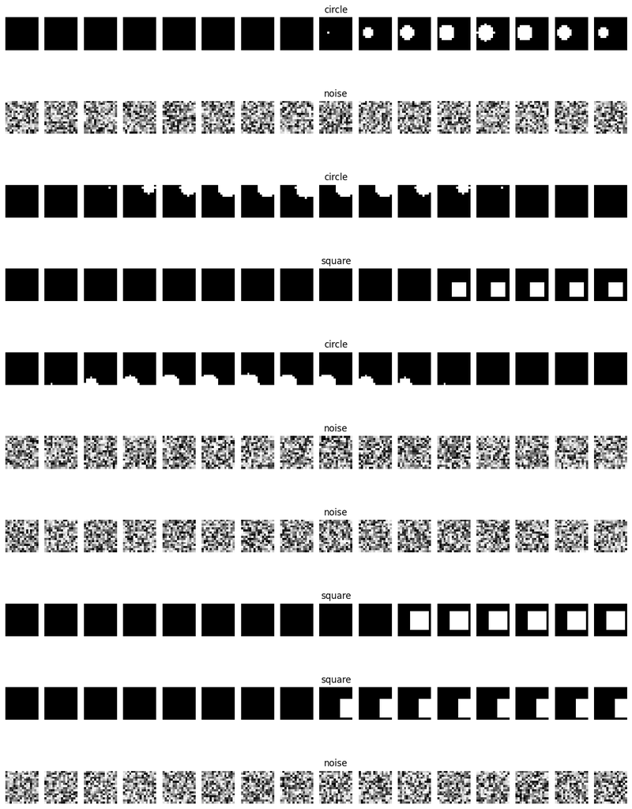

```python
def generate_square(shape: Tuple[int] = (16, 16, 16)) -> np.ndarray:
    img = np.zeros(shape)
    corner = np.asarray(shape) // 4 + np.random.randint(0, shape[0] // 2, 3)
    side = np.random.randint(shape[1] / 3, shape[1] * 2 / 3)

    idx = np.asarray(np.meshgrid(*[np.arange(side) for _ in range(3)])).T.reshape(-1, 3)
    idx += corner
    maxes = np.amax(idx, axis=-1)
    idx = idx[maxes < shape[0]]

    img[tuple(idx.T)] = 1

    return img

def generate_circle(shape: Tuple[int] = (16, 16, 16)) -> np.ndarray:
    img = np.zeros(shape)
    center = np.random.randint(0, shape[0], 3)
    radius = np.random.randint(shape[0] // 4, shape[0] // 2)

    idx = np.asarray(np.meshgrid(*[np.arange(x) for x in shape])).T.reshape(-1, 3)
    distances = euclidean_distances(idx, center.reshape(1, -1))[:,0]
    inside = distances <= radius

    img[tuple(idx[inside].T)] = 1

    return img

def generate_noise(shape: Tuple[int] = (16, 16, 16)) -> np.ndarray:
    return np.random.uniform(0, 1, shape)

n = 200
shape = 16
squares = np.asarray([generate_square(shape=(shape, shape, shape)) for _ in range(n)])
circles = np.asarray([generate_circle(shape=(shape, shape, shape)) for _ in range(n)])
noise = np.asarray([generate_noise(shape=(shape, shape, shape)) for _ in range(n)])
X = np.concatenate([squares, circles, noise], axis=0)
y = np.asarray((['square'] * n) + (['circle'] * n) + (['noise'] * n))
idx = np.random.permutation(np.arange(len(X)))
X = np.reshape(X, (-1, shape, shape, shape, 1))
X = X[idx]
y = y[idx]

print(f'X.shape: {X.shape}')
print(f'y.shape: {y.shape}')

n = 10
fig, ax = plt.subplots(n, shape, figsize=(15, 2 * n))

for i in range(n):
    ax[i][shape // 2].set_title(str(y[i]))
    for j in range(shape):
        ax[i][j].imshow(X[i, j], cmap='Greys_r')
        ax[i][j].axis('off')

fig.savefig(target_dir / '1_geometric_samples_overview.png', bbox_inches='tight', dpi=150)
plt.show()
plt.close(fig)

encoder = OneHotEncoder()
y = encoder.fit_transform(y.reshape(-1, 1)).toarray()

train_X = X[:300]
train_y = y[:300]
test_X = X[:300]
test_y = y[:300]
```

## 2.1 Interpretation: Übersicht über die Stichproben

↑ Inhaltsverzeichnis

### Wie diese Abbildung zu lesen ist

Ein 3D-Volumen kann man auf einem flachen Bildschirm nicht direkt zeigen. Die übliche Darstellung — dieselbe, die auch Radiologen am Befundungsmonitor nutzen — ist die **Schnittbildreihe**: Man schneidet das Volumen entlang einer Achse in Scheiben und legt diese nebeneinander.

Die Abbildung hat also folgende Struktur:

- **Jede Zeile** ist *ein* Trainingsbeispiel, mit dem Klassennamen als Überschrift über der Mitte.
- **Jede der 16 Spalten** ist eine Schnittebene $z = 0, 1, \dots, 15$ durch dieses eine Volumen. Man liest eine Zeile also wie ein Daumenkino, das sich durch das Objekt hindurchbewegt.
- Weiß bedeutet Voxelwert 1, schwarz bedeutet 0 (Colormap `Greys_r`, das `_r` steht für *reversed*).

### Was man konkret sieht

**Kugeln (`circle`)** erscheinen als Kreisscheiben, die über die Schnitte hinweg **wachsen und wieder schrumpfen**. Das ist genau die Signatur einer Kugel: Schneidet man eine Kugel mit Radius $r$ in der Höhe $h$ über dem Zentrum, hat der Querschnitt den Radius $\sqrt{r^2 - h^2}$ — maximal in der Mitte, null an den Polen. In der ersten Zeile sieht man das mustergültig: Bei Schnitt 8 ein einzelner heller Punkt, bei Schnitt 12 die größte Scheibe, danach wieder kleiner.

**Würfel (`square`)** erscheinen dagegen als Quadrate **konstanter Größe**, die über mehrere aufeinanderfolgende Schnitte unverändert stehen und dann abrupt verschwinden. Auch das ist geometrisch zwingend: Ein achsenparalleler Querschnitt durch einen Würfel ist immer dasselbe Quadrat.

**Rauschen (`noise`)** ist in jedem einzelnen Schnitt körnig und sieht in allen 16 Schnitten gleich aus. Es gibt keine räumliche Kohärenz — der Wert eines Voxels sagt nichts über seine Nachbarn.

### Die wichtigste Beobachtung: abgeschnittene Objekte

> Ein Teil der Stichproben trägt ein Label (`circle` oder `square`), obwohl das sichtbare Objekt kaum noch Kugel- oder Würfelcharakter hat. Man spricht von **Label-Rauschen**. Es setzt eine Obergrenze für die erreichbare Genauigkeit, die *unterhalb* von 100 % liegt — kein Modell kann Information rekonstruieren, die in den Daten nicht mehr vorhanden ist. Halten Sie das im Kopf, wenn wir in Abschnitt 8 sehen, dass das Modell zwischen Kugel und Würfel oft nur mäßig sicher entscheidet.

## 2.2 Vorverarbeitung: One-Hot-Kodierung und Datensplit

↑ Inhaltsverzeichnis

### One-Hot-Kodierung

Neuronale Netze rechnen mit Zahlen, nicht mit Strings. Die Labels `'circle'`, `'noise'`, `'square'` müssen also numerisch werden. Man könnte einfach 0, 1, 2 vergeben — das wäre aber falsch, denn es würde eine **Ordnung** suggerieren („noise liegt zwischen circle und square“), die es nicht gibt.

Der `OneHotEncoder` bildet stattdessen jede Klasse auf einen Einheitsvektor ab:

$$\texttt{circle} \mapsto (1,0,0), \qquad \texttt{noise} \mapsto (0,1,0), \qquad \texttt{square} \mapsto (0,0,1)$$

Alle Klassen haben damit denselben Abstand voneinander. `y` bekommt die Form `(600, 3)`. Diese Kodierung passt genau zur Verlustfunktion, die wir gleich verwenden (kategorische Kreuzentropie), und zur Softmax-Ausgabeschicht mit drei Neuronen.

### Der Datensplit — und ein bewusst stehengelassener Fallstrick

Die letzten vier Zeilen teilen die Daten in Trainings- und Testmenge auf. Schauen Sie genau hin:

```
train_X = X[:300]
test_X  = X[:300]   # identischer Bereich!
```

**Trainings- und Testmenge sind dieselben 300 Stichproben.** Das ist in produktivem Code ein schwerer Fehler und heißt *Datenleck* (data leakage): Die gemessene Validierungsgenauigkeit sagt dann nichts über die **Generalisierungsfähigkeit** aus, sondern nur darüber, wie gut das Modell seine Trainingsdaten auswendig gelernt hat. Korrekt wäre etwa `test_X = X[300:]`, sodass die zweiten 300 Stichproben ungesehen bleiben.

Warum ist das hier vertretbar? Weil das Ziel dieses Notebooks nicht das Erreichen einer belastbaren Testgenauigkeit ist, sondern die Demonstration von LRP. Für die Erklärungen selbst spielt es keine Rolle, ob das Bild aus dem Training stammt. Wichtig ist nur, dass Sie **die genannten Genauigkeitswerte nicht als Leistungsaussage lesen** — und dass Sie den Fehler in Ihrem eigenen Code nicht wiederholen. Der Vollständigkeit halber: Die Stichproben mit Index 300 bis 599 werden in diesem Notebook überhaupt nicht verwendet.

# 3. Das 3D-CNN aufbauen und trainieren

↑ Inhaltsverzeichnis

## Der größere Kontext: Warum Faltungsnetze?

Man könnte die 4096 Voxel einfach in einen langen Vektor auffalten und ein klassisches, vollverbundenes Netz darauf ansetzen. Das wäre aus zwei Gründen schlecht:

1. **Parameterexplosion.** Schon eine erste versteckte Schicht mit 100 Neuronen bräuchte $4096 \times 100 \approx 410.000$ Gewichte — mehr als wir Trainingsbeispiele haben.
2. **Verlust der Nachbarschaft.** Beim Auffalten geht die Information verloren, welche Voxel räumlich benachbart sind. Genau diese Information *ist* aber die Form eines Objekts.

**Convolutional Neural Networks (CNNs)** lösen beides durch zwei Ideen: *lokale Verbindungen* (jedes Neuron sieht nur einen kleinen Bildausschnitt) und *Gewichtsteilung* (dasselbe Filter wird über das gesamte Bild geschoben). Ein Filter, das eine Kante erkennt, muss so nur einmal gelernt werden und funktioniert an jeder Position. Diese Eigenschaft heißt **Translationsäquivarianz** und ist der Grund, warum CNNs die Bildverarbeitung seit 2012 dominieren.

Formal berechnet eine 3D-Faltung für Ausgabekanal $c$ an Position $(i,j,k)$:

$$z^{c}_{ijk} = \sum_{d}\sum_{u=-1}^{1}\sum_{v=-1}^{1}\sum_{w=-1}^{1} w^{c,d}_{uvw} \cdot a^{d}_{i+u,\,j+v,\,k+w} \;+\; b^{c}$$

Dabei läuft $d$ über die Eingabekanäle und $w^{c,d}$ ist der $3\times3\times3$-Kern. Ein solcher Kern hat 27 Gewichte — unabhängig von der Bildgröße.

## Was diese Zelle berechnet

Das Netz besteht aus **vier identisch aufgebauten Blöcken**, gefolgt von einem Klassifikationskopf. Jeder Block enthält:

**`Conv3D(k, (3,3,3), padding='SAME', kernel_regularizer=l2(1e-3))`** — die Faltung mit $k$ Filtern. `padding='SAME'` legt einen Rahmen aus Nullen um das Volumen, damit die Ausgabe dieselbe räumliche Größe wie die Eingabe hat. Der `l2`-Regularisierer addiert $\lambda \sum_i w_i^2$ mit $\lambda = 10^{-3}$ zum Verlust und drängt die Gewichte so gegen null — eine Standardmaßnahme gegen **Overfitting** (das Auswendiglernen der Trainingsdaten).

**`BatchNormalization()`** — normalisiert die Ausgaben über den Mini-Batch:

$$\hat{z} = \gamma \cdot \frac{z - \mu_{\text{batch}}}{\sqrt{\sigma^2_{\text{batch}} + \epsilon}} + \beta$$

mit den gelernten Parametern $\gamma$ (Skalierung) und $\beta$ (Verschiebung). Das stabilisiert und beschleunigt das Training erheblich. Merken Sie sich diese Schicht — sie wird in Abschnitt 5 für LRP eine besondere Rolle spielen.

**`Activation('relu')`** — die Nichtlinearität $\text{ReLU}(x) = \max(0, x)$. Ohne Nichtlinearität wäre die Verkettung mehrerer Schichten mathematisch äquivalent zu einer einzigen linearen Abbildung, und das Netz könnte nichts lernen, was komplexer als eine lineare Funktion ist. Dass Faltung und Aktivierung hier *getrennte* Schichten sind (statt `Conv3D(..., activation='relu')`), ist kein Zufall: LRP muss zwischen der linearen Operation und der Aktivierung unterscheiden können.

**`MaxPooling3D((2,2,2))`** — fasst jeden $2\times2\times2$-Block zu seinem Maximum zusammen und **halbiert damit jede Raumdimension**. Das reduziert den Rechenaufwand und vergrößert das **rezeptive Feld**: Nach mehreren Pooling-Stufen „sieht“ ein einzelnes Neuron einen großen Teil des Originalvolumens.

Die räumliche Auflösung entwickelt sich also so:

| Stufe | Form (D×H×W×Kanäle) |
| --- | --- |
| Eingabe | 16 × 16 × 16 × 1 |
| nach Block 1 | 8 × 8 × 8 × 8 |
| nach Block 2 | 4 × 4 × 4 × 16 |
| nach Block 3 | 2 × 2 × 2 × 32 |
| nach Block 4 | 1 × 1 × 1 × 32 |

Das ist das typische CNN-Muster: **räumlich schrumpfen, in der Kanaltiefe wachsen**. Aus vielen Ortsangaben mit wenig Bedeutung werden wenige Ortsangaben mit viel Bedeutung.

Der Kopf besteht aus:

- **`Flatten()`** — macht aus dem $1\times1\times1\times32$-Tensor einen Vektor mit 32 Einträgen.
- **`Dropout(0.5)`** — schaltet während des Trainings zufällig die Hälfte der Neuronen ab. Das verhindert, dass sich das Netz auf einzelne Neuronen verlässt, und wirkt wie ein Ensemble vieler kleinerer Netze. Bei der Inferenz ist Dropout automatisch inaktiv.
- **`Dense(3, activation='softmax')`** — drei Ausgabeneuronen, eines pro Klasse. Die Softmax-Funktion

  $$p_c = \frac{e^{z_c}}{\sum_{c'} e^{z_{c'}}}$$

  verwandelt die drei rohen Werte (*Logits*) in eine Wahrscheinlichkeitsverteilung, die sich zu 1 summiert.

Insgesamt hat das Modell rund 46.000 Parameter — für ein neuronales Netz sehr wenig (ein ResNet-50 hat 25 Millionen), aber angemessen für 300 Trainingsbeispiele.

## Training

`model.compile(...)` legt fest, *wie* gelernt wird:

- **Verlustfunktion:** kategorische Kreuzentropie. Für ein Beispiel mit One-Hot-Label $y$ und Vorhersage $p$ gilt

  $$\mathcal{L} = -\sum_{c} y_c \log p_c$$

  Weil nur eine Komponente von $y$ gleich 1 ist, reduziert sich das auf $-\log p_{\text{korrekte Klasse}}$: Der Verlust ist null bei perfekter Sicherheit und wächst unbeschränkt, je näher die vorhergesagte Wahrscheinlichkeit der richtigen Klasse an null rückt.
- **Optimierer:** Adam mit Lernrate $10^{-4}$. Adam passt die Schrittweite pro Parameter adaptiv an und ist der De-facto-Standard.
- **Metrik:** Accuracy, also der Anteil korrekt klassifizierter Beispiele. Anders als der Verlust ist sie direkt interpretierbar, aber nicht differenzierbar und deshalb nicht als Optimierungsziel geeignet.

Der `if`-Block darunter implementiert **Caching**: Liegt unter `output/notebooks/.../100_epochs/` bereits eine `.keras`-Datei, wird sie geladen; andernfalls wird 100 Epochen lang trainiert und das Ergebnis gespeichert. Eine *Epoche* ist ein vollständiger Durchgang durch die Trainingsdaten; bei `batch_size=32` und 300 Beispielen sind das 10 Gewichtsaktualisierungen pro Epoche. Dieses Caching-Muster macht das Notebook beim erneuten Ausführen schnell und die Erklärungen von Lauf zu Lauf vergleichbar — bei XAI-Experimenten ein wichtiger Vorteil, denn ein anderes Modell ergibt andere Heatmaps.

```python
from tensorflow.keras import Model
from tensorflow.keras.layers import Activation, BatchNormalization, Conv3D, Dense, Dropout, \
                                    Flatten, GlobalAveragePooling3D, Input, MaxPooling3D, Reshape
from tensorflow.keras.models import load_model
from tensorflow.keras.optimizers import Adam
from tensorflow.keras.regularizers import l2

MODEL_DIR = repo_root / "output" / "notebooks" / notebook_name / "100_epochs"
MODEL_DIR.mkdir(parents=True, exist_ok=True)
MODEL_PATH = MODEL_DIR / "geometric_3d_cnn.keras"

input = Input((shape, shape, shape, 1))
x = input

x = Conv3D(8, (3, 3, 3), padding='SAME', activation=None, kernel_regularizer=l2(1e-3))(x)
x = BatchNormalization()(x)
x = Activation('relu')(x)
x = MaxPooling3D((2, 2, 2))(x)

x = Conv3D(16, (3, 3, 3), padding='SAME', activation=None, kernel_regularizer=l2(1e-3))(x)
x = BatchNormalization()(x)
x = Activation('relu')(x)
x = MaxPooling3D((2, 2, 2))(x)

x = Conv3D(32, (3, 3, 3), padding='SAME', activation=None, kernel_regularizer=l2(1e-3))(x)
x = BatchNormalization()(x)
x = Activation('relu')(x)
x = MaxPooling3D((2, 2, 2))(x)

x = Conv3D(32, (3, 3, 3), padding='SAME', activation=None, kernel_regularizer=l2(1e-3))(x)
x = BatchNormalization()(x)
x = Activation('relu')(x)
x = MaxPooling3D((2, 2, 2))(x)

x = Flatten()(x)
x = Dropout(0.5)(x)
x = Dense(3, activation='softmax')(x)

model = Model(input, x)

model.compile(loss='categorical_crossentropy', optimizer=Adam(1e-4), metrics=['accuracy'])

existing_model_path = next(iter(sorted(MODEL_DIR.glob("*.keras"))), None)

if existing_model_path is not None:
    model = load_model(existing_model_path)
    print(f"Model geladen von: {existing_model_path}")
else:
    model.fit(
        train_X,
        train_y,
        validation_data=(test_X, test_y),
        batch_size=32,
        epochs=100,
    )

    model.save(MODEL_PATH)
    print(f"Model gespeichert unter: {MODEL_PATH}")
```

[output not shown]

[output not shown]

```
Model geladen von: /mnt/users/andreasre/git-repos/keras-explainability/output/notebooks/Train_and_explain_dummy_geometric_data/100_epochs/geometric_3d_cnn.keras
```

## 3.1 Interpretation: Was beim Training passiert ist

↑ Inhaltsverzeichnis

Die Ausgabe dieser Zelle enthält keinen Trainingsverlauf, sondern nur die Meldung `Model geladen von: .../geometric_3d_cnn.keras`. Das ist die erwartete Ausgabe **beim zweiten und jedem weiteren Lauf**: Das Modell wurde bereits einmal trainiert und liegt als Datei vor, der `else`-Zweig mit `model.fit(...)` wird übersprungen.

Beim allerersten Lauf sähen Sie hier stattdessen 100 Zeilen mit Fortschrittsbalken und Kennzahlen der Art `loss: 0.31 - accuracy: 0.92 - val_loss: 0.29 - val_accuracy: 0.93`. Die beiden Größen mit `val_`-Präfix beziehen sich auf die Validierungsdaten und sind hier — siehe Abschnitt 2.2 — mit den Trainingsdaten identisch, also nicht aussagekräftig.

# 4. Die Schichten des Modells zählen

↑ Inhaltsverzeichnis

## Was diese Zelle berechnet

`len(model.layers)` gibt die Anzahl der Keras-Schichten aus. Das Ergebnis ist **20**, und diese Zahl setzt sich so zusammen:

$$\underbrace{1}_{\text{Input}} + \underbrace{4 \times 4}_{\text{Conv, BN, ReLU, Pool}} + \underbrace{1}_{\text{Flatten}} + \underbrace{1}_{\text{Dropout}} + \underbrace{1}_{\text{Dense}} = 20$$

## Warum das gleich wichtig wird

Diese scheinbar triviale Zelle ist eine Vorbereitung: LRP muss wissen, *an welcher Schicht* die Erklärung beginnen soll. Der Index wird in der nächsten Zelle als `N_layers = len(model.layers) - 1 = 19` berechnet — also der Index der **letzten** Schicht, der `Dense(3, softmax)`-Ausgabeschicht (Python zählt ab 0, der letzte gültige Index ist demnach 19).

Der Ausdruck `len(model.layers) - 1` ist robuster, als eine Zahl fest einzutippen: Wer der Architektur später einen Block hinzufügt, muss nichts anpassen. Die auskommentierten Zeilen `#N_layers = 9` und `#N_layers = 32` im nächsten Codeblock sind Überreste früherer Experimente mit anderen Architekturen — ein guter Anlass für den Hinweis, dass man Erklärungen prinzipiell auch an *Zwischen*schichten abgreifen kann, um zu untersuchen, was das Netz auf mittlerer Abstraktionsebene repräsentiert.

```python
print(len(model.layers))
```

```
20
```

# 5. Layer-wise Relevance Propagation (LRP)

↑ Inhaltsverzeichnis

## Der größere Kontext: Die Landschaft der XAI-Methoden

Wir haben ein Modell, das klassifiziert. Jetzt wollen wir wissen: **Welche Voxel haben zu dieser Entscheidung beigetragen?** Für diese Frage gibt es mehrere Antwortstrategien:

| Ansatz | Idee | Bekannte Vertreter |
| --- | --- | --- |
| Gradientenbasiert | Wie stark ändert sich die Ausgabe, wenn ich ein Voxel minimal ändere? | Saliency Maps, Grad-CAM, Integrated Gradients |
| Perturbationsbasiert | Was passiert, wenn ich Bildbereiche verdecke? | Occlusion, LIME, SHAP |
| Rückpropagation von Relevanz | Verteile die Ausgabe schichtweise rückwärts auf die Eingabe | **LRP**, DeepLIFT |

Reine Gradienten haben einen bekannten Schwachpunkt: Sie messen *lokale Sensitivität*, nicht *Beitrag*. Ein Voxel kann für die Entscheidung entscheidend sein und trotzdem einen Gradienten von null haben, wenn die Aktivierung gesättigt ist. LRP wurde 2015 von Bach et al. genau deshalb entwickelt und liefert typischerweise deutlich weniger verrauschte Karten.

## Die Kernidee von LRP: Erhaltung

LRP beruht auf einem einzigen Prinzip, dem **Konservierungsprinzip**. Man startet mit der Ausgabe des Netzes für die interessierende Klasse $c$ und verteilt diesen Wert rückwärts durch alle Schichten, wobei in jedem Schritt die Gesamtsumme erhalten bleibt:

$$\sum_i R_i^{(1)} = \dots = \sum_j R_j^{(l)} = \sum_k R_k^{(l+1)} = \dots = f_c(x)$$

Am Ende hat jedes Eingabevoxel $i$ einen **Relevanzwert** $R_i$. Positive Relevanz heißt „dieses Voxel hat für die Klasse gesprochen“, negative Relevanz „es hat dagegen gesprochen“. Diese Vorzeicheninformation ist ein wesentlicher Vorteil gegenüber Methoden, die nur Betragsstärken liefern.

Die Aufteilung innerhalb einer Schicht geschieht proportional zum Beitrag jedes Neurons. Die Grundregel (LRP-0) lautet:

$$R_i = \sum_j \frac{a_i w_{ij}}{\sum_{i'} a_{i'} w_{i'j} + b_j} \; R_j$$

Dabei ist $a_i$ die Aktivierung von Neuron $i$, $w_{ij}$ das Gewicht zu Neuron $j$ der nächsten Schicht und $R_j$ die dort vorliegende Relevanz. Der Bruch ist genau der relative Anteil, den $i$ am Eingang von $j$ hatte.

In dieser reinen Form ist LRP-0 numerisch instabil: Wird der Nenner nahe null, explodiert der Quotient. Deshalb existieren stabilisierte Varianten, von denen zwei in diesem Notebook zum Einsatz kommen:

**Die $\varepsilon$-Regel** addiert einen kleinen Term im Nenner:

$$R_i = \sum_j \frac{a_i w_{ij}}{z_j + \varepsilon \cdot \operatorname{sign}(z_j)} \; R_j, \qquad z_j = \sum_{i'} a_{i'} w_{i'j} + b_j$$

Das dämpft schwache, verrauschte Beiträge und ergibt schärfere Karten. Der Preis: Die Relevanzsumme ist nur noch näherungsweise erhalten (ein Teil wird „absorbiert“).

**Die $\alpha\beta$-Regel** trennt positive und negative Beiträge und gewichtet sie unterschiedlich:

$$R_i = \sum_j \left( \alpha \frac{(a_i w_{ij})^+}{\sum_{i'} (a_{i'} w_{i'j})^+} \; - \; \beta \frac{(a_i w_{ij})^-}{\sum_{i'} (a_{i'} w_{i'j})^-} \right) R_j$$

mit der Nebenbedingung $\alpha - \beta = 1$, die die Erhaltung sicherstellt. $(\cdot)^+$ bezeichnet den positiven, $(\cdot)^-$ den negativen Anteil. Bei $\alpha = 2, \beta = 1$ — den Werten dieses Notebooks — werden also Beiträge *für* die Klasse doppelt gewichtet und Beiträge *gegen* sie einfach abgezogen. Man erhält so kontrastreiche Karten, die klar zeigen, was die Entscheidung getragen hat. Die Implementierung erzwingt diese Bedingung übrigens per `assert alpha == beta + 1`.

## Was diese Zelle berechnet

`LRP(model, layer=N_layers, idx=i, strategy=strategy)` baut ein **zweites Keras-Modell**, das rückwärts läuft. Diese Konstruktion ist der Kern des `explainability`-Pakets dieses Repositories, und sie ist elegant: Die Rückpropagation ist selbst ein Graph aus Keras-Schichten, lässt sich also mit `.predict()` aufrufen und auf der GPU ausführen. Intern passieren dabei drei Vorbereitungsschritte, die man kennen sollte:

1. **Die Softmax wird entfernt** (`remove_activation`). Erklärt wird der rohe Logit $z_c$, nicht die Wahrscheinlichkeit $p_c$. Der Grund: Die Softmax normalisiert über alle Klassen, ihr Wert für Klasse $c$ hängt damit auch von den anderen Klassen ab — das würde die Zuordnung von Relevanz verfälschen.
2. **BatchNormalization wird in die Faltung hineingerechnet** (`fuse_batchnorm`). Da BatchNorm zur Inferenzzeit eine feste affine Abbildung ist, kann man sie in die Gewichte der vorangehenden Faltung einrechnen. Danach sieht LRP eine saubere Kette aus lineare Operation → Aktivierung, für die die obigen Regeln definiert sind.
3. **Die Zielklasse wird maskiert.** Die Startrelevanz ist $R_j^{(L)} = z_j \cdot \delta_{j, \texttt{idx}}$, also der Logit der gewünschten Klasse an ihrer Position und null überall sonst. Genau deshalb braucht man **pro Klasse einen eigenen Erklärer** — und deshalb legt die Dictionary-Comprehension am Ende drei Objekte an, eines für `circle`, `noise` und `square`.

Die Schleife, die `layer.rate = 0.0` für alle Dropout-Schichten setzt, ist eine Sicherheitsmaßnahme: Zufälliges Ausschalten von Neuronen würde Erklärungen von Aufruf zu Aufruf verändern. Bei der Inferenz ist Dropout ohnehin inaktiv, aber im rückwärts laufenden LRP-Graphen möchte man sich darauf nicht verlassen.

## 5.1 Die LRP-Strategie dieses Notebooks

↑ Inhaltsverzeichnis

Ein wichtiges Ergebnis der LRP-Forschung (Montavon et al., 2019) lautet: **Es gibt nicht eine beste Regel, sondern eine beste Regel pro Schichttyp.** Die empfohlene Aufteilung für Faltungsnetze:

- **Untere Schichten** (nahe der Eingabe): Regeln, die den Wertebereich der Eingabe berücksichtigen, damit die Karte nicht verrauscht wird.
- **Mittlere Schichten:** $\alpha\beta$ (bzw. $\gamma$), für kontrastreiche, räumlich lokalisierte Erklärungen.
- **Obere Schichten** (nahe der Ausgabe): $\varepsilon$, zur Rauschunterdrückung.

Genau das kodiert `LRPStrategy`. Die Liste enthält einen Eintrag pro Schicht mit Gewichten und ist **in Vorwärtsrichtung** (Eingabe → Ausgabe) notiert; intern wird sie mit `[::-1]` umgedreht, weil der LRP-Graph rückwärts läuft. Das Modell hat fünf gewichtsbehaftete Schichten (vier `Conv3D` plus ein `Dense`), und die Liste muss genau fünf Einträge haben — andernfalls schlägt eine `assert`-Prüfung fehl. Die Zuordnung ist damit:

| Eintrag | Schicht im Modell | Regel |
| --- | --- | --- |
| `{'b': True}` | Conv3D #1 (8 Filter) | Aktivierungen werden durch Einsen ersetzt |
| `{'alpha': 2, 'beta': 1}` | Conv3D #2 (16 Filter) | $\alpha\beta$-Regel |
| `{'alpha': 2, 'beta': 1}` | Conv3D #3 (32 Filter) | $\alpha\beta$-Regel |
| `{'alpha': 2, 'beta': 1}` | Conv3D #4 (32 Filter) | $\alpha\beta$-Regel |
| `{'epsilon': 0.5}` | Dense (3 Ausgaben) | $\varepsilon$-Regel |

Die erste Zeile verdient eine Erläuterung. Das Flag `b` bewirkt in der Implementierung `a = tf.ones_like(a)`: Die Eingabeaktivierungen der ersten Faltung werden durch Einsen ersetzt, sodass die Relevanzverteilung dort nur noch von den Gewichten abhängt. Der Effekt ist eine gleichmäßigere, weniger intensitätsabhängige Karte in der Eingabeschicht. Das ist verwandt mit der $z^{\mathcal{B}}$-Regel, die für Eingaben mit bekanntem Wertebereich entworfen wurde — bei unseren Daten liegt dieser Bereich sauber in $[0,1]$.

Für die vier `MaxPooling3D`-Schichten wird keine Strategie angegeben, es gilt also der Standard **winner-takes-all**: Die Relevanz eines Pooling-Ausgangs geht vollständig an dasjenige Voxel, das im Vorwärtspass das Maximum war. Das ist konsistent mit der Vorwärtsoperation und der Grund, warum die Erklärungen räumlich präzise bleiben, obwohl vier Halbierungsschritte dazwischen liegen.

```python
from explainability import LRP, LRPStrategy


alpha = 2
beta = 1

strategy = LRPStrategy(
    layers=[
        {'b': True},
        {'alpha': alpha, 'beta': beta},
        {'alpha': alpha, 'beta': beta},
        {'alpha': alpha, 'beta': beta},
        {'epsilon': 0.5}
    ]
)
#N_layers = 9
#N_layers = 32
N_layers = len(model.layers)-1

for layer in model.layers:
    if "dropout" in layer.name.lower():
        layer.rate = 0.0

explainers = {
    encoder.categories_[0][i]: LRP(model, layer=N_layers, idx=i, strategy=strategy) \
    for i in range(3)
}
```

# 6. Die Reihenfolge der Klassen

↑ Inhaltsverzeichnis

## Was diese Zelle berechnet

`encoder.categories_[0]` gibt die Klassennamen in genau der Reihenfolge zurück, in der der `OneHotEncoder` sie den Spalten zugeordnet hat. Die Ausgabe ist

```
array(['circle', 'noise', 'square'], dtype='<U6')
```

Die Reihenfolge ist **alphabetisch** — nicht die Reihenfolge, in der die Daten erzeugt wurden (dort war es Würfel, Kugel, Rauschen). Spalte 0 des Ausgabevektors entspricht also `circle`, Spalte 1 `noise`, Spalte 2 `square`.

## Warum eine so kleine Zelle ihren eigenen Abschnitt bekommt

Diese Zeile sieht nach Beiwerk aus, verhindert aber einen der häufigsten und unangenehmsten Fehler im Machine Learning: **die Verwechslung von Klassenindizes**. Ein solcher Fehler produziert keinen Programmabbruch. Das Modell trainiert normal, die Metriken sehen plausibel aus, und nur die Beschriftung der Ergebnisse ist falsch — bei einer Erklärungsanalyse bedeutet das, dass man die Heatmap der Klasse A betrachtet und über Klasse B nachdenkt.

Der übrige Code schützt sich dagegen, indem er die Klassennamen konsequent aus dem Encoder ableitet, statt sie irgendwo neu einzutippen:

```
explainers = {encoder.categories_[0][i]: LRP(..., idx=i, ...) for i in range(3)}
```

Der Index `i`, der an LRP als Zielklasse übergeben wird, und der Name, unter dem der Erklärer im Dictionary landet, stammen damit aus derselben Quelle und können nicht auseinanderlaufen. Das ist eine kleine Regel mit großem Nutzen: **Beschriftungen immer aus der Datenquelle ableiten, nie parallel pflegen.**

```python
encoder.categories_[0]
```

```
array(['circle', 'noise', 'square'], dtype='<U6')
```

# 7. Erklärungen für echte Stichproben

↑ Inhaltsverzeichnis

## Was diese Zelle berechnet

Für die ersten zehn Stichproben aus `test_X` wird jeweils

1. das **Eingabevolumen** als Schnittbildreihe gezeichnet (Titel: `Image <Klasse>`),
2. und danach für **jede der drei Klassen** eine LRP-Erklärung berechnet und ebenfalls als Schnittbildreihe gezeichnet.

Pro Stichprobe entstehen also vier Bildreihen, insgesamt 40. Entscheidend ist, dass alle drei Erklärungen zum *gleichen* Eingabebild gehören. Wir fragen das Netz gewissermaßen dreimal etwas Verschiedenes:

- *Was an diesem Bild spricht für eine Kugel?*
- *Was spricht für Rauschen?*
- *Was spricht für einen Würfel?*

Diese **klassenspezifische** Betrachtung ist eine der Stärken von LRP. Man erklärt nicht „die Vorhersage“ als Ganzes, sondern kann jede Hypothese einzeln befragen — auch solche, die das Netz verworfen hat.

## Die Normalisierung der Darstellung

```
explanation = explanation / np.amax(np.abs(explanation))
```

Diese Zeile teilt die Relevanzkarte durch ihren größten Absolutwert, sodass alle Werte in $[-1, 1]$ liegen:

$$\tilde{R} = \frac{R}{\max_i |R_i|}$$

Das ist nötig, weil die Rohwerte von der Größe des Logits abhängen und von Bild zu Bild um Größenordnungen schwanken können. Nach der Normalisierung passt jede Karte zur festen Farbskala `clim=(-1, 1)`, und die Bilder sind untereinander vergleichbar.

Ein wichtiger Vorbehalt: Die Normalisierung ist **relativ zum jeweiligen Bild**. Ein sattes Rot bedeutet „das stärkste Signal *in diesem Bild*“ — nicht „ein starkes Signal absolut“. Zwei Karten können optisch gleich kräftig aussehen und doch zu völlig unterschiedlich sicheren Vorhersagen gehören.

## Die Farbskala verstehen

Alle Erklärungsbilder verwenden die divergierende Colormap `seismic`, die um null zentriert ist:

| Farbe | Relevanz | Bedeutung |
| --- | --- | --- |
| **Rot** | $R > 0$ | Dieses Voxel **spricht für** die genannte Klasse |
| **Weiß** | $R \approx 0$ | Kein nennenswerter Beitrag |
| **Blau** | $R < 0$ | Dieses Voxel **spricht gegen** die Klasse |

Divergierende Colormaps sind bei vorzeichenbehafteten Größen die richtige Wahl. Eine Skala wie `viridis` oder `jet` würde negative und positive Relevanz ununterscheidbar machen und damit die Hälfte der Information verschenken.

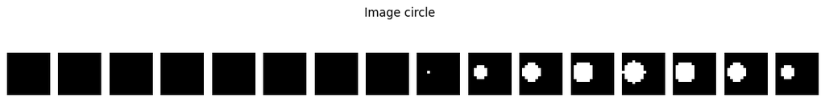

[output not shown]

```
1/1 ━━━━━━━━━━━━━━━━━━━━ 0s 3s/step
```

```
1/1 ━━━━━━━━━━━━━━━━━━━━ 3s 3s/step
```

```
I0000 00:00:1786052605.996684   25849 device_compiler.h:208] Compiled cluster using XLA!  This line is logged at most once for the lifetime of the process.
```

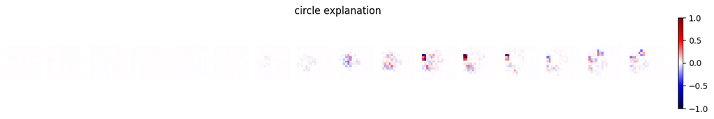

```
1/1 ━━━━━━━━━━━━━━━━━━━━ 0s 1s/step
```

```
1/1 ━━━━━━━━━━━━━━━━━━━━ 1s 1s/step
```

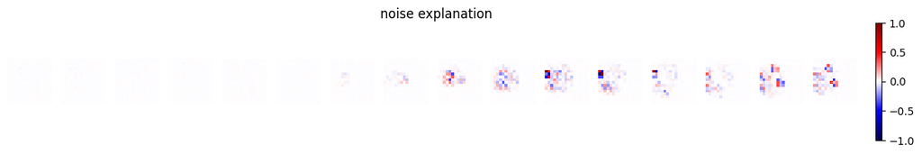

```
1/1 ━━━━━━━━━━━━━━━━━━━━ 0s 1s/step
```

```
1/1 ━━━━━━━━━━━━━━━━━━━━ 1s 1s/step
```

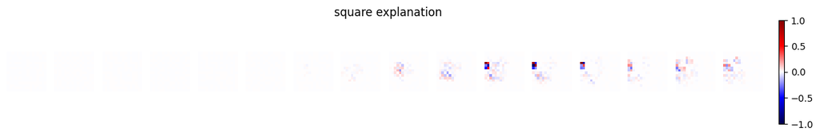

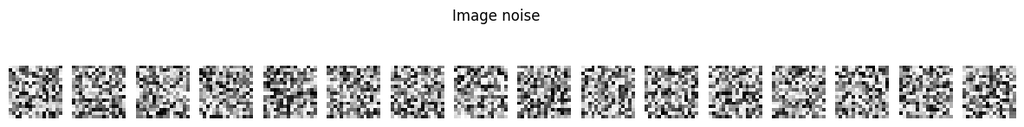

```
1/1 ━━━━━━━━━━━━━━━━━━━━ 0s 17ms/step
```

```
1/1 ━━━━━━━━━━━━━━━━━━━━ 0s 30ms/step
```

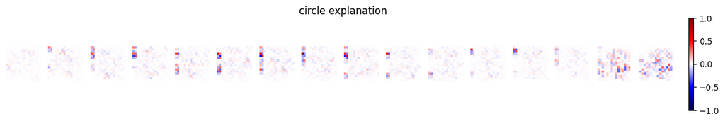

```
1/1 ━━━━━━━━━━━━━━━━━━━━ 0s 17ms/step
```

```
1/1 ━━━━━━━━━━━━━━━━━━━━ 0s 31ms/step
```

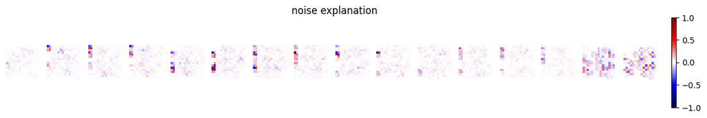

```
1/1 ━━━━━━━━━━━━━━━━━━━━ 0s 16ms/step
```

```
1/1 ━━━━━━━━━━━━━━━━━━━━ 0s 29ms/step
```

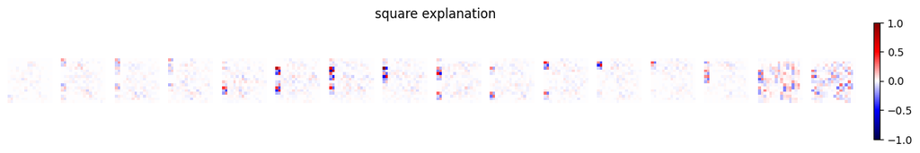

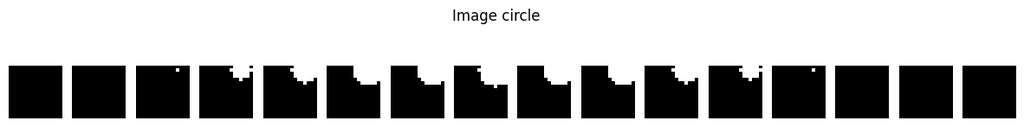

```
1/1 ━━━━━━━━━━━━━━━━━━━━ 0s 17ms/step
```

```
1/1 ━━━━━━━━━━━━━━━━━━━━ 0s 30ms/step
```

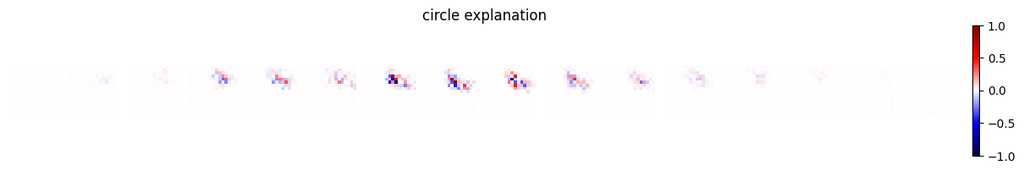

```
1/1 ━━━━━━━━━━━━━━━━━━━━ 0s 17ms/step
```

```
1/1 ━━━━━━━━━━━━━━━━━━━━ 0s 30ms/step
```

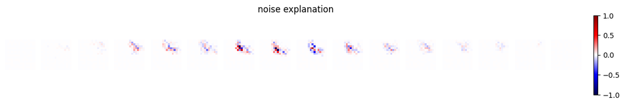

```
1/1 ━━━━━━━━━━━━━━━━━━━━ 0s 17ms/step
```

```
1/1 ━━━━━━━━━━━━━━━━━━━━ 0s 30ms/step
```

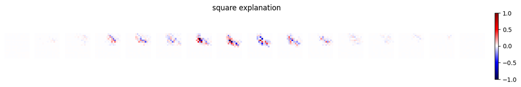

[28 more figures not shown]

```python
for i in range(10):
    img = test_X[i]
    label = encoder.categories_[0][np.argmax(test_y[i])]

    fig, ax = plt.subplots(1, shape, figsize=(15, 2))
    fig.suptitle(f'Image {label}')
    for i in range(shape):
        ax[i].imshow(img[i], cmap='Greys_r')
        ax[i].axis('off')
    plt.show()

    for classname in encoder.categories_[0]:
        explanation = explainers[classname].predict(np.expand_dims(img, axis=0))
        explanation = explanation / np.amax(np.abs(explanation))

        fig, ax = plt.subplots(1, shape, figsize=(15, 2))
        fig.suptitle(f'{classname} explanation')
        for j in range(shape):
            im = ax[j].imshow(explanation[0,j], cmap='seismic', clim=(-1, 1))
            ax[j].axis('off')
        fig.colorbar(im, ax=ax, fraction=0.02, pad=0.02)
        plt.show()

fig.savefig(target_dir / '2_geometric_samples_explanations.png', bbox_inches='tight', dpi=150)
plt.show()
plt.close(fig)
```

## 7.1 Interpretation: Die Heatmaps der Stichproben

↑ Inhaltsverzeichnis

Die Ausgabe ist lang — 40 Bildreihen. Statt sie einzeln durchzugehen, lohnt es sich, auf vier Muster zu achten, die sich durch alle Beispiele ziehen.

### Beobachtung 1: Ein auffälliges Artefakt am Bildrand

**Zero-Padding.** Die Faltungen verwenden `padding='SAME'`, legen also einen Rahmen aus Nullen um das Volumen. Für ein Neuron am Rand ist ein Teil des rezeptiven Felds daher künstlich null, und der Nenner der LRP-Regel, $z_j = \sum_i a_i w_{ij}$, wird betragsmäßig klein. Da die Relevanz durch diesen Nenner geteilt wird, wächst der Quotient dort stark an — ein Randeffekt, der durch vier Faltungsschichten hindurch verstärkt wird.

**Aggressives Pooling.** Vier `MaxPooling3D`-Stufen reduzieren $16^3$ auf $1^3$. Am Ende gibt es genau *eine* räumliche Position, und die winner-takes-all-Rückverteilung muss die gesamte Relevanz über vier Stufen auf einen einzigen Pfad zurückführen. Kleine Asymmetrien in der Indizierung — etwa welches Voxel bei Gleichstand als Maximum gilt — schlagen dabei systematisch auf bestimmte Randpositionen durch.

> **Praxislehre:** Das ist keine Randnotiz, sondern die zentrale Lektion dieses Abschnitts. Eine Heatmap ist nie eine neutrale Wahrheit, sondern das Produkt aus Modell, LRP-Regelwahl, Architektur *und* Darstellungsentscheidungen. Bevor man aus einer Erklärung eine Aussage über das Modell ableitet, muss man wissen, welche Strukturen methodisch bedingt sind. Bei echten Anwendungen begegnet man solchen Artefakten ständig — und die Versuchung, sie inhaltlich zu deuten („das Modell achtet auf den Bildrand!“), ist groß.

### Beobachtung 2: Das Signal folgt trotzdem dem Objekt

Interessant ist das Zusammenspiel von Rot und Blau innerhalb einer Objektregion. Bei der Kugel liegen die Farben oft dicht beieinander, statt die Kugel flächig rot zu füllen. Das ist charakteristisch: Das Netz hat mit $3\times3\times3$-Filtern vor allem **Kanten und Krümmung** gelernt, nicht „Fläche“. Die informative Struktur ist die Objektgrenze, und dort erzeugt ein Kantenfilter naturgemäß benachbarte positive und negative Antworten.

### Beobachtung 3: Rauschen sieht völlig anders aus

Vergleichen Sie die Erklärungen für ein `noise`-Bild mit denen für ein geometrisches Objekt. Bei Rauschen ist die Relevanz **über das gesamte Volumen verstreut**, in allen 16 Schnitten, mit deutlich kräftigeren Farben und ohne jede räumliche Konzentration. Auch das ist genau richtig: Bei Rauschen *gibt* es keine lokalisierte Evidenz. Die Klasse ist an der Textur des ganzen Volumens erkennbar, nicht an einer Stelle.

Diese qualitative Unterscheidung — *lokalisiert* versus *global verstreut* — ist ein Ergebnis, das man in einer reinen Genauigkeitszahl nicht sehen würde. Die Erklärung sagt uns nicht nur, *wo* das Modell hinschaut, sondern auch, *welcher Art* die Evidenz ist.

### Beobachtung 4: Die drei Klassenerklärungen ähneln sich

Ein kritischer Punkt: Betrachtet man dasselbe Eingabebild dreimal (für `circle`, `noise` und `square`), sind die Karten sich strukturell **ähnlicher, als man erwarten würde**. Sie unterscheiden sich in Details und teils im Vorzeichen, aber die grobe räumliche Verteilung stimmt weitgehend überein.

Dieses Phänomen ist in der Literatur gut dokumentiert und wird als mangelnde **Klassensensitivität** von Attributionsmethoden kritisiert. Es hat hier eine naheliegende Erklärung: Nach vier Pooling-Stufen bleiben nur 32 Zahlen übrig, und alle drei Klassen lesen dieselben 32 Merkmale — lediglich mit anderen Gewichten in der letzten Schicht. Die räumliche Herkunft der Relevanz ist damit zwangsläufig für alle Klassen sehr ähnlich. Wer klar getrennte klassenspezifische Karten will, braucht ein Modell mit mehr räumlicher Auflösung vor der Klassifikation.

### Ein technischer Hinweis zur gespeicherten Datei

Der `savefig`-Aufruf steht *nach* der Schleife und bezieht sich damit auf die Variable `fig`, die zu diesem Zeitpunkt nur noch die **letzte** erzeugte Figur enthält. Die Datei `2_geometric_samples_explanations.png` zeigt deshalb nicht alle 40 Reihen, sondern eine einzige. Im Notebook selbst sind alle Reihen sichtbar, weil `plt.show()` innerhalb der Schleife aufgerufen wird. Genau dieses Problem löst Abschnitt 9, in dem alles in *eine* Figur mit vielen Zeilen gezeichnet und dann als Ganzes gespeichert wird.

# 8. Das Gegenprobe-Experiment: Hybrid-Objekte

↑ Inhaltsverzeichnis

## Der größere Kontext: Erklärungen sind Hypothesen, die man testen muss

Bis hierhin haben wir Heatmaps *betrachtet*. Das ist eine notorisch unzuverlässige Form der Validierung, denn menschliche Mustererkennung findet auch dort Struktur, wo keine ist. Die Forschung hat gezeigt, dass plausibel *aussehende* Erklärungen von Modellen stammen können, die nachweislich Unsinn gelernt haben — und dass manche Attributionsmethoden Karten produzieren, die sich kaum ändern, wenn man die Modellgewichte randomisiert (Adebayo et al., 2018).

Dieser Abschnitt geht deshalb einen Schritt weiter und führt ein **kontrolliertes Experiment** durch. Wir konstruieren Eingaben, für die wir eine klare Erwartung formulieren können, und prüfen, ob Vorhersage und Erklärung dieser Erwartung folgen. Das ist der Übergang von *beobachtender* zu *experimenteller* Interpretierbarkeit — methodisch dasselbe Vorgehen wie in der Physiologie, wo man einen Reiz gezielt variiert, statt nur zu beobachten.

## Was diese Zelle berechnet

**Schritt 1: Zwei perfekte Referenzobjekte.** Anders als im Trainingsdatensatz werden hier ein Würfel und eine Kugel *deterministisch* und *exakt zentriert* erzeugt:

- `square[4:12, 4:12, 4:12] = 1` — ein Würfel mit Kantenlänge 8, mittig im Volumen.
- Eine Kugel mit Zentrum $(8,8,8)$ und Radius 4, gezeichnet über eine dreifach verschachtelte Schleife mit der Bedingung $\|p - z\|_2 \le 4$.

Beide sind vollständig sichtbar, nicht abgeschnitten und haben dieselbe Ausdehnung. Das eliminiert die Störgrößen aus Abschnitt 2.1.

**Schritt 2: Sechs Hybride.** Aus den beiden Objekten werden per `np.concatenate` **Chimären** gebaut: Die eine Hälfte des Volumens stammt vom Würfel, die andere von der Kugel. Das geschieht für alle drei Raumachsen und in beiden Reihenfolgen, also $3 \times 2 = 6$ Kombinationen. Zum Beispiel:

```
np.concatenate([square[:8], circle[8:]], axis=0)   # vorne Würfel, hinten Kugel
np.concatenate([circle[:8], square[8:]], axis=0)   # umgekehrt
```

Diese Objekte sind **out-of-distribution**: Sie gehören zu keiner Trainingsklasse und wurden dem Modell nie gezeigt. Genau das macht sie wertvoll — sie erzwingen eine Entscheidung zwischen zwei gleichzeitig vorhandenen Evidenzen und zeigen so, wie das Modell Beweise abwägt.

**Schritt 3: Vorhersage und Erklärung.** Für jedes Hybrid wird die Vorhersage berechnet (und als Titel über der Bildreihe angezeigt), dann eine Erklärung pro Klasse.

**Schritt 4: Das Differenzbild.** Der interessanteste Teil. Hier werden die Erklärungen für `square` und `circle` zunächst *unterschiedlich* normalisiert, nämlich auf den Bereich $[0,1]$ per Min-Max:

$$R^{\text{norm}} = \frac{R - \min_i R_i}{\max_i (R_i - \min_i R_i)}$$

und anschließend voneinander abgezogen:

$$D = R^{\text{norm}}_{\text{square}} - R^{\text{norm}}_{\text{circle}}$$

Die Idee ist eine **kontrastive Erklärung**: Nicht „was spricht für Würfel“, sondern „was spricht *eher* für Würfel als für Kugel“. Rot markiert dann Regionen, die die Würfel-Hypothese relativ stärker stützen, blau solche, die die Kugel-Hypothese stützen. Bei einem sauber arbeitenden Modell und einem Hybrid erwarten wir Rot in der Würfelhälfte und Blau in der Kugelhälfte.

> **Methodische Warnung zur Differenz.** Die Min-Max-Normalisierung verschiebt den Nullpunkt: Nach der Transformation ist der kleinste (also negativste) Relevanzwert 0 und nicht mehr „kein Beitrag“. Die Differenz zweier so skalierter Karten mischt daher echte Kontrastinformation mit Skalierungseffekten, und beide Karten können unterschiedliche Skalenfaktoren erhalten haben. Die Variablenbezeichnung `absolute_difference` ist zusätzlich irreführend, denn es wird kein Absolutbetrag gebildet — das Vorzeichen bleibt erhalten, und das ist gut so, sonst wäre die Richtung des Kontrasts verloren. Das Differenzbild taugt als qualitativer Hinweis, nicht als quantitatives Maß.

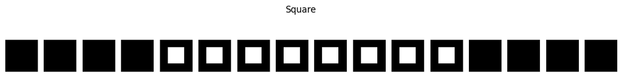

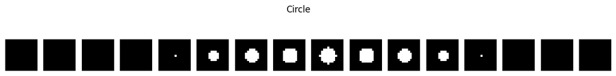

```
1/1 ━━━━━━━━━━━━━━━━━━━━ 0s 661ms/step
```

```
1/1 ━━━━━━━━━━━━━━━━━━━━ 1s 675ms/step
```

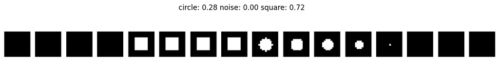

```
1/1 ━━━━━━━━━━━━━━━━━━━━ 0s 17ms/step
```

```
1/1 ━━━━━━━━━━━━━━━━━━━━ 0s 30ms/step
```

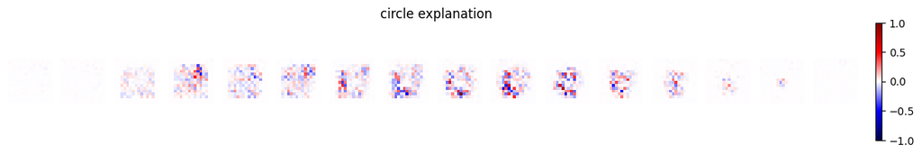

```
1/1 ━━━━━━━━━━━━━━━━━━━━ 0s 18ms/step
```

```
1/1 ━━━━━━━━━━━━━━━━━━━━ 0s 32ms/step
```

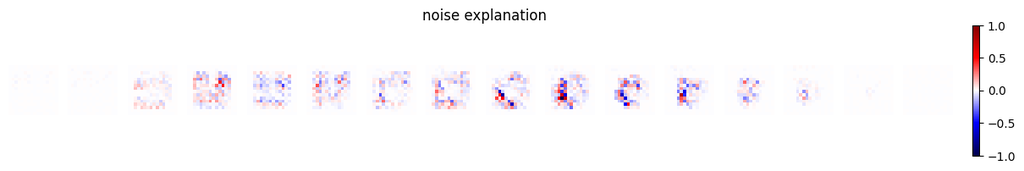

```
1/1 ━━━━━━━━━━━━━━━━━━━━ 0s 17ms/step
```

```
1/1 ━━━━━━━━━━━━━━━━━━━━ 0s 31ms/step
```

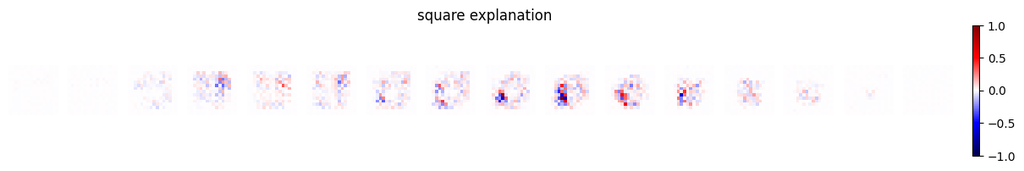

```
1/1 ━━━━━━━━━━━━━━━━━━━━ 0s 17ms/step
```

```
1/1 ━━━━━━━━━━━━━━━━━━━━ 0s 30ms/step
```

```
1/1 ━━━━━━━━━━━━━━━━━━━━ 0s 16ms/step
```

```
1/1 ━━━━━━━━━━━━━━━━━━━━ 0s 29ms/step
```

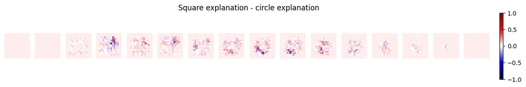

```
1/1 ━━━━━━━━━━━━━━━━━━━━ 0s 18ms/step
```

```
1/1 ━━━━━━━━━━━━━━━━━━━━ 0s 31ms/step
```

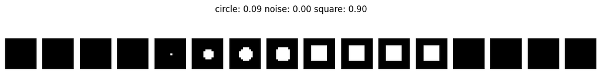

```
1/1 ━━━━━━━━━━━━━━━━━━━━ 0s 16ms/step
```

```
1/1 ━━━━━━━━━━━━━━━━━━━━ 0s 29ms/step
```

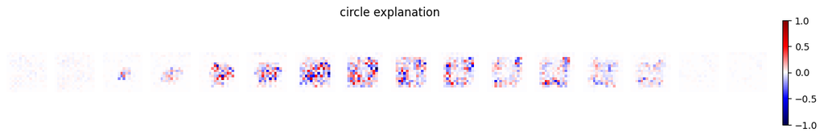

```
1/1 ━━━━━━━━━━━━━━━━━━━━ 0s 17ms/step
```

```
1/1 ━━━━━━━━━━━━━━━━━━━━ 0s 31ms/step
```

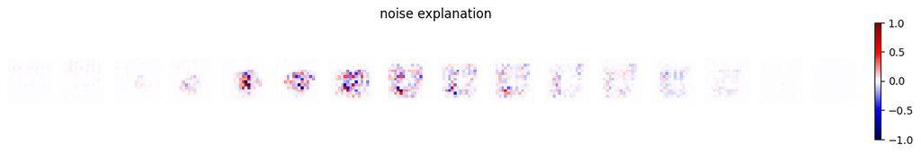

```
1/1 ━━━━━━━━━━━━━━━━━━━━ 0s 17ms/step
```

```
1/1 ━━━━━━━━━━━━━━━━━━━━ 0s 30ms/step
```

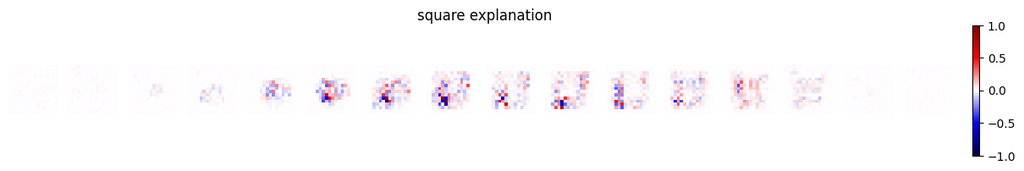

```
1/1 ━━━━━━━━━━━━━━━━━━━━ 0s 17ms/step
```

```
1/1 ━━━━━━━━━━━━━━━━━━━━ 0s 30ms/step
```

```
1/1 ━━━━━━━━━━━━━━━━━━━━ 0s 16ms/step
```

```
1/1 ━━━━━━━━━━━━━━━━━━━━ 0s 29ms/step
```

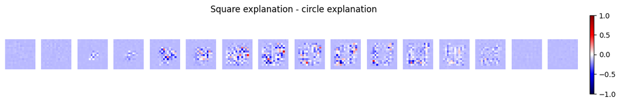

```
1/1 ━━━━━━━━━━━━━━━━━━━━ 0s 15ms/step
```

```
1/1 ━━━━━━━━━━━━━━━━━━━━ 0s 28ms/step
```

[20 more figures not shown]

```python
from scipy.spatial.distance import euclidean


labels = encoder.categories_[0]

square = np.zeros((16, 16, 16, 1))
square[4:12,4:12,4:12,0] = 1

fig, ax = plt.subplots(1, shape, figsize=(15, 2))
fig.suptitle('Square')
for j in range(shape):
    ax[j].imshow(square[j], cmap='Greys_r')
    ax[j].axis('off')
plt.show()

circle = np.zeros((16, 16, 16, 1))
center = (8, 8, 8)
radius = 4

for i in range(16):
    for j in range(16):
        for k in range(16):
            if euclidean((i, j, k), center) <= radius:
                circle[i,j,k,0] = 1

fig, ax = plt.subplots(1, shape, figsize=(15, 2))
fig.suptitle('Circle')
for j in range(shape):
    ax[j].imshow(circle[j], cmap='Greys_r')
    ax[j].axis('off')
plt.show()

combinations = [
    np.concatenate([square[:8], circle[8:]], axis=0),
    np.concatenate([circle[:8], square[8:]], axis=0),
    np.concatenate([square[:,:8], circle[:,8:]], axis=1),
    np.concatenate([circle[:,:8], square[:,8:]], axis=1),
    np.concatenate([square[:,:,:8], circle[:,:,8:]], axis=2),
    np.concatenate([circle[:,:,:8], square[:,:,8:]], axis=2),
]

for i in range(len(combinations)):
    fig, ax = plt.subplots(1, shape, figsize=(15, 2))
    prediction = model.predict(np.expand_dims(combinations[i], axis=0))[0]
    fig.suptitle(' '.join([f'{labels[i]}: {prediction[i]:.2f}' for i in range(len(labels))]))

    for j in range(shape):
        ax[j].imshow(combinations[i][j], cmap='Greys_r')
        ax[j].axis('off')

    plt.show()

    for j in range(3):
        fig, ax = plt.subplots(1, shape, figsize=(15, 2))
        classname = encoder.categories_[0][j]
        explanation = explainers[classname].predict(np.expand_dims(combinations[i], axis=0))[0]
        explanation = explanation / np.amax(np.abs(explanation))
        fig.suptitle(f'{classname} explanation')

        for k in range(shape):
            im = ax[k].imshow(explanation[k], cmap='seismic', clim=(-1, 1))
            ax[k].axis('off')
        fig.colorbar(im, ax=ax, fraction=0.02, pad=0.02)
        plt.show()

    square_explanation = explainers['square'].predict(np.expand_dims(combinations[i], axis=0))[0]
    square_explanation = square_explanation - np.amin(square_explanation)
    square_explanation = square_explanation / np.amax(square_explanation)
    circle_explanation = explainers['circle'].predict(np.expand_dims(combinations[i], axis=0))[0]
    circle_explanation = circle_explanation - np.amin(circle_explanation)
    circle_explanation = circle_explanation / np.amax(circle_explanation)
    absolute_difference = square_explanation - circle_explanation

    fig, ax = plt.subplots(1, shape, figsize=(15, 2))
    fig.suptitle('Square explanation - circle explanation')

    for j in range(shape):
        im = ax[j].imshow(absolute_difference[j], cmap='seismic', clim=(-1, 1))
        ax[j].axis('off')
    fig.colorbar(im, ax=ax, fraction=0.02, pad=0.02)
    plt.show()
```

## 8.1 Interpretation: Vorhersagen und Erklärungen der Hybride

↑ Inhaltsverzeichnis

### Die Referenzobjekte

Die ersten beiden Bildreihen zeigen den perfekten Würfel und die perfekte Kugel. Der Würfel erscheint in den Schnitten 4 bis 11 als identisches Quadrat, die Kugel als Scheibe, die von Schnitt 4 bis 8 wächst und bis Schnitt 12 wieder schrumpft. Das sind die Idealformen, gegen die wir alles Weitere vergleichen.

### Wie man die Hybride in der Schnittdarstellung erkennt

Die sechs Kombinationen sehen unterschiedlich aus, je nachdem, entlang welcher Achse geschnitten wurde — ein Punkt, der leicht verwirrt:

- **`axis=0`** ist genau die Achse, entlang der auch die Schnittbilder angeordnet sind. Man sieht daher *reine* Bilder: die Schnitte 4 bis 7 zeigen ein Würfelquadrat, die Schnitte 8 bis 11 eine Kugelscheibe (oder umgekehrt).
- **`axis=1` und `axis=2`** schneiden *innerhalb* jedes Bildes. Jeder einzelne Schnitt ist deshalb selbst ein Mischbild: oben flach und eckig, unten gerundet — bzw. links und rechts bei `axis=2`. Diese Formen sehen aus wie halbe Quadrate mit angesetzter Kuppe.

### Beobachtung 1: `noise` ist immer exakt 0.00

In allen sechs Titelzeilen steht `noise: 0.00`. Das Modell schließt Rauschen mit maximaler Sicherheit aus — bei Objekten, die es nie gesehen hat.

Das ist gleichzeitig beruhigend und verdächtig. Beruhigend, weil die Hybride tatsächlich strukturiert sind. Verdächtig, weil eine Wahrscheinlichkeit von exakt null bei *out-of-distribution*-Eingaben auf eine sehr einfache Entscheidungsregel hindeutet. Erinnern Sie sich an Abschnitt 2: Rauschen war die einzige Klasse mit kontinuierlichen Werten und einer mittleren Intensität von etwa 0.5, während Würfel und Kugeln binär sind und nur einen Bruchteil des Volumens füllen. Das Modell hat mit hoher Wahrscheinlichkeit den **Intensitäts-Shortcut** gelernt statt eines echten Texturkonzepts. Für diesen Datensatz funktioniert das perfekt; auf Daten mit anderem Intensitätsprofil würde es sofort zusammenbrechen.

Die sechs Vorhersagen lauten:

[output not shown]

### Beobachtung 3: Die fehlende Symmetrie ist das eigentlich Aufschlussreiche

**Das Modell ist also positionsabhängig.** Wo die Würfelhälfte liegt, beeinflusst das Ergebnis, obwohl gleich viel Würfelevidenz vorhanden ist. Auf den ersten Blick widerspricht das dem Lehrbuchargument, CNNs seien translationsäquivariant. Der Widerspruch löst sich, wenn man die Architektur betrachtet: Vier Pooling-Stufen reduzieren $16^3$ auf $1^3$, und das anschließende `Flatten` mit `Dense`-Schicht verknüpft *feste* Positionen mit *festen* Gewichten. Die Äquivarianz der Faltung wird durch die Ausgabearchitektur wieder aufgegeben. Genau solche Einsichten sind der Grund, warum man kontrollierte Experimente macht: Diese Positionsabhängigkeit ist in keiner Genauigkeitszahl sichtbar.

### Beobachtung 4: Das Differenzbild liefert nicht, was es sollte

Dieses Negativergebnis ist lehrreich, und es hat zwei getrennte Ursachen:

1. **Methodisch:** Der gleichmäßige Farbstich ist ein Artefakt der Min-Max-Normalisierung. Weil beide Karten vor der Subtraktion auf $[0,1]$ verschoben und *unabhängig* voneinander skaliert werden, unterscheiden sich ihre Nullpunkte, und die Differenz enthält einen konstanten Offset. Man betrachtet also zu einem guten Teil einen Skalierungseffekt, nicht einen inhaltlichen Kontrast.
2. **Inhaltlich:** Die beiden Karten *sind* sich tatsächlich sehr ähnlich — dieselbe Beobachtung wie in Abschnitt 7.1. Wenn `square`- und `circle`-Erklärung nahezu identisch sind, ist ihre Differenz notwendigerweise nahe null. Nach vier Pooling-Stufen bleiben nur 32 gemeinsam genutzte Merkmale, aus denen alle Klassen lesen; eine klassenspezifische räumliche Trennung ist bei dieser Architektur strukturell kaum möglich.

### Was wir aus dem Experiment mitnehmen

Das Experiment hat funktioniert, auch wenn die Erklärungen nicht so hübsch geworden sind wie erhofft. Es hat drei konkrete Eigenschaften des Modells aufgedeckt: einen Würfel-Bias, eine Positionsabhängigkeit und einen mutmaßlichen Intensitäts-Shortcut für die Rauschklasse. Und es hat eine Grenze der Methode gezeigt: In dieser Architektur — mit vier Pooling-Stufen bis auf eine einzige räumliche Position — sind klassenspezifische Erklärungen kaum zu trennen. Wer diesen Aspekt untersuchen möchte, sollte weniger aggressiv poolen oder die Erklärung an einer *Zwischen*schicht abgreifen (siehe die Bemerkung zum `layer`-Parameter in Abschnitt 4).

**Ein negatives Ergebnis ehrlich zu benennen, ist Teil der Methode.** Eine Erklärung, die nichts zeigt, ist eine Information über Modell und Methode — nicht ein Anlass, Parameter zu drehen, bis das erwartete Bild erscheint.

# 9. Alles in einer Abbildung

↑ Inhaltsverzeichnis

## Was diese Zelle berechnet

Inhaltlich rechnet diese Zelle **exakt dasselbe** wie Abschnitt 8: dieselben Referenzobjekte, dieselben sechs Hybride, dieselben Vorhersagen und Erklärungen. Der Unterschied liegt ausschließlich in der Darstellung — und der ist praktisch bedeutsam.

Statt viele einzelne Figuren zu erzeugen, wird **eine** Figur mit

$$n_{\text{rows}} = \underbrace{2}_{\text{Referenzen}} + \underbrace{6}_{\text{Hybride}} \times \underbrace{(1 + 3 + 1)}_{\text{Eingabe, 3 Erklärungen, Differenz}} = 32$$

Zeilen und 16 Spalten angelegt. Die Hilfsfunktion `plot_row` zeichnet eine Zeile und erhöht dabei einen Zeilenzähler; sie greift über `global row` auf diesen Zähler zu — ein pragmatisches, wenn auch nicht besonders elegantes Muster für Notebook-Code.

## Warum dieser Umweg?

Aus dem Problem, auf das Abschnitt 7.1 am Ende hingewiesen hat: `fig.savefig()` kann nur die Figur speichern, auf die die Variable gerade zeigt. Werden in einer Schleife 30 Figuren erzeugt, landet nur die letzte in der Datei. Alles in eine Figur zu zeichnen, löst das — die vollständige Analyse liegt danach als eine einzige Datei `3_geometric_combinations_explanations.png` vor.

Das ist keine kosmetische Frage. Reproduzierbare Forschung heißt unter anderem, dass Abbildungen **automatisch aus dem Code entstehen** und nicht per Screenshot aus einem Notebook gezogen werden. Nur so ist garantiert, dass die Abbildung in der Publikation tatsächlich zu dem Code gehört, der im Repository liegt. Der Parameter `dpi=150` sorgt zusätzlich dafür, dass die Auflösung für Druck und Präsentation ausreicht, und `bbox_inches='tight'` schneidet überflüssige Ränder ab.

```
1/1 ━━━━━━━━━━━━━━━━━━━━ 0s 16ms/step
```

```
1/1 ━━━━━━━━━━━━━━━━━━━━ 0s 30ms/step
```

```
1/1 ━━━━━━━━━━━━━━━━━━━━ 0s 16ms/step
```

```
1/1 ━━━━━━━━━━━━━━━━━━━━ 0s 29ms/step
```

```
1/1 ━━━━━━━━━━━━━━━━━━━━ 0s 16ms/step
```

```
1/1 ━━━━━━━━━━━━━━━━━━━━ 0s 29ms/step
```

```
1/1 ━━━━━━━━━━━━━━━━━━━━ 0s 16ms/step
```

```
1/1 ━━━━━━━━━━━━━━━━━━━━ 0s 29ms/step
```

```
1/1 ━━━━━━━━━━━━━━━━━━━━ 0s 16ms/step
```

```
1/1 ━━━━━━━━━━━━━━━━━━━━ 0s 29ms/step
```

```
1/1 ━━━━━━━━━━━━━━━━━━━━ 0s 16ms/step
```

```
1/1 ━━━━━━━━━━━━━━━━━━━━ 0s 29ms/step
```

```
1/1 ━━━━━━━━━━━━━━━━━━━━ 0s 16ms/step
```

```
1/1 ━━━━━━━━━━━━━━━━━━━━ 0s 29ms/step
```

```
1/1 ━━━━━━━━━━━━━━━━━━━━ 0s 16ms/step
```

```
1/1 ━━━━━━━━━━━━━━━━━━━━ 0s 29ms/step
```

```
1/1 ━━━━━━━━━━━━━━━━━━━━ 0s 16ms/step
```

```
1/1 ━━━━━━━━━━━━━━━━━━━━ 0s 29ms/step
```

```
1/1 ━━━━━━━━━━━━━━━━━━━━ 0s 17ms/step
```

```
1/1 ━━━━━━━━━━━━━━━━━━━━ 0s 29ms/step
```

```
1/1 ━━━━━━━━━━━━━━━━━━━━ 0s 16ms/step
```

```
1/1 ━━━━━━━━━━━━━━━━━━━━ 0s 29ms/step
```

```
1/1 ━━━━━━━━━━━━━━━━━━━━ 0s 16ms/step
```

```
1/1 ━━━━━━━━━━━━━━━━━━━━ 0s 30ms/step
```

```
1/1 ━━━━━━━━━━━━━━━━━━━━ 0s 16ms/step
```

```
1/1 ━━━━━━━━━━━━━━━━━━━━ 0s 29ms/step
```

```
1/1 ━━━━━━━━━━━━━━━━━━━━ 0s 16ms/step
```

```
1/1 ━━━━━━━━━━━━━━━━━━━━ 0s 29ms/step
```

```
1/1 ━━━━━━━━━━━━━━━━━━━━ 0s 16ms/step
```

```
1/1 ━━━━━━━━━━━━━━━━━━━━ 0s 29ms/step
```

```
1/1 ━━━━━━━━━━━━━━━━━━━━ 0s 16ms/step
```

```
1/1 ━━━━━━━━━━━━━━━━━━━━ 0s 29ms/step
```

```
1/1 ━━━━━━━━━━━━━━━━━━━━ 0s 16ms/step
```

```
1/1 ━━━━━━━━━━━━━━━━━━━━ 0s 29ms/step
```

```
1/1 ━━━━━━━━━━━━━━━━━━━━ 0s 16ms/step
```

```
1/1 ━━━━━━━━━━━━━━━━━━━━ 0s 29ms/step
```

```
1/1 ━━━━━━━━━━━━━━━━━━━━ 0s 16ms/step
```

```
1/1 ━━━━━━━━━━━━━━━━━━━━ 0s 29ms/step
```

```
1/1 ━━━━━━━━━━━━━━━━━━━━ 0s 16ms/step
```

```
1/1 ━━━━━━━━━━━━━━━━━━━━ 0s 30ms/step
```

```
1/1 ━━━━━━━━━━━━━━━━━━━━ 0s 16ms/step
```

```
1/1 ━━━━━━━━━━━━━━━━━━━━ 0s 29ms/step
```

```
1/1 ━━━━━━━━━━━━━━━━━━━━ 0s 16ms/step
```

```
1/1 ━━━━━━━━━━━━━━━━━━━━ 0s 30ms/step
```

```
1/1 ━━━━━━━━━━━━━━━━━━━━ 0s 16ms/step
```

```
1/1 ━━━━━━━━━━━━━━━━━━━━ 0s 29ms/step
```

```
1/1 ━━━━━━━━━━━━━━━━━━━━ 0s 16ms/step
```

```
1/1 ━━━━━━━━━━━━━━━━━━━━ 0s 29ms/step
```

```
1/1 ━━━━━━━━━━━━━━━━━━━━ 0s 16ms/step
```

```
1/1 ━━━━━━━━━━━━━━━━━━━━ 0s 29ms/step
```

```
1/1 ━━━━━━━━━━━━━━━━━━━━ 0s 17ms/step
```

```
1/1 ━━━━━━━━━━━━━━━━━━━━ 0s 29ms/step
```

```
1/1 ━━━━━━━━━━━━━━━━━━━━ 0s 17ms/step
```

```
1/1 ━━━━━━━━━━━━━━━━━━━━ 0s 30ms/step
```

```
1/1 ━━━━━━━━━━━━━━━━━━━━ 0s 16ms/step
```

```
1/1 ━━━━━━━━━━━━━━━━━━━━ 0s 30ms/step
```

```
1/1 ━━━━━━━━━━━━━━━━━━━━ 0s 26ms/step
```

```
1/1 ━━━━━━━━━━━━━━━━━━━━ 0s 39ms/step
```

```
1/1 ━━━━━━━━━━━━━━━━━━━━ 0s 16ms/step
```

```
1/1 ━━━━━━━━━━━━━━━━━━━━ 0s 29ms/step
```

```
1/1 ━━━━━━━━━━━━━━━━━━━━ 0s 16ms/step
```

```
1/1 ━━━━━━━━━━━━━━━━━━━━ 0s 29ms/step
```

```
1/1 ━━━━━━━━━━━━━━━━━━━━ 0s 17ms/step
```

```
1/1 ━━━━━━━━━━━━━━━━━━━━ 0s 30ms/step
```

```
1/1 ━━━━━━━━━━━━━━━━━━━━ 0s 16ms/step
```

```
1/1 ━━━━━━━━━━━━━━━━━━━━ 0s 29ms/step
```

```
1/1 ━━━━━━━━━━━━━━━━━━━━ 0s 17ms/step
```

```
1/1 ━━━━━━━━━━━━━━━━━━━━ 0s 30ms/step
```

```
1/1 ━━━━━━━━━━━━━━━━━━━━ 0s 16ms/step
```

```
1/1 ━━━━━━━━━━━━━━━━━━━━ 0s 30ms/step
```

```
1/1 ━━━━━━━━━━━━━━━━━━━━ 0s 16ms/step
```

```
1/1 ━━━━━━━━━━━━━━━━━━━━ 0s 29ms/step
```

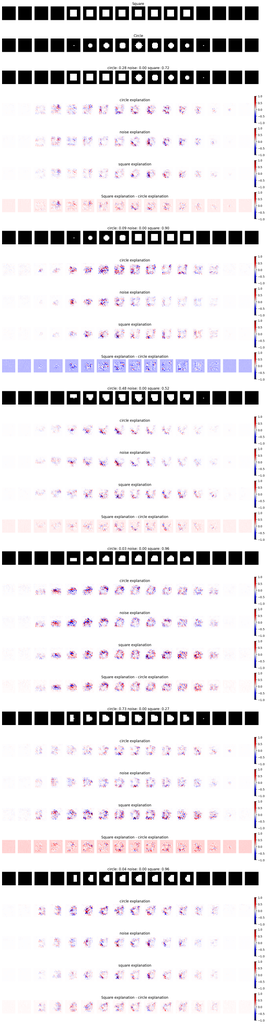

```python
from scipy.spatial.distance import euclidean

labels = encoder.categories_[0]

square = np.zeros((16, 16, 16, 1))
square[4:12, 4:12, 4:12, 0] = 1

circle = np.zeros((16, 16, 16, 1))
center = (8, 8, 8)
radius = 4
for i in range(16):
    for j in range(16):
        for k in range(16):
            if euclidean((i, j, k), center) <= radius:
                circle[i, j, k, 0] = 1

combinations = [
    np.concatenate([square[:8], circle[8:]], axis=0),
    np.concatenate([circle[:8], square[8:]], axis=0),
    np.concatenate([square[:, :8], circle[:, 8:]], axis=1),
    np.concatenate([circle[:, :8], square[:, 8:]], axis=1),
    np.concatenate([square[:, :, :8], circle[:, :, 8:]], axis=2),
    np.concatenate([circle[:, :, :8], square[:, :, 8:]], axis=2),
]

# Square + Circle + je Combination: Input + 3 Erklärungen + Differenz
n_rows = 2 + len(combinations) * (1 + 3 + 1)
fig, ax = plt.subplots(n_rows, shape, figsize=(16, 2 * n_rows))
row = 0

def plot_row(data, title, cmap='Greys_r', clim=None, colorbar=False):
    global row
    ax[row][shape // 2].set_title(title)
    im = None
    for j in range(shape):
        kwargs = {'cmap': cmap}
        if clim is not None:
            kwargs['clim'] = clim
        im = ax[row][j].imshow(data[j], **kwargs)
        ax[row][j].axis('off')
    if colorbar:
        fig.colorbar(im, ax=ax[row], fraction=0.015, pad=0.01)
    row += 1

plot_row(square, 'Square')
plot_row(circle, 'Circle')

for i, combo in enumerate(combinations):
    prediction = model.predict(np.expand_dims(combo, axis=0))[0]
    title = ' '.join([f'{labels[c]}: {prediction[c]:.2f}' for c in range(len(labels))])
    plot_row(combo, title)

    for classname in labels:
        explanation = explainers[classname].predict(np.expand_dims(combo, axis=0))[0]
        explanation = explanation / np.amax(np.abs(explanation))
        plot_row(explanation, f'{classname} explanation',
                 cmap='seismic', clim=(-1, 1), colorbar=True)

    square_explanation = explainers['square'].predict(np.expand_dims(combo, axis=0))[0]
    square_explanation = square_explanation - np.amin(square_explanation)
    square_explanation = square_explanation / np.amax(square_explanation)
    circle_explanation = explainers['circle'].predict(np.expand_dims(combo, axis=0))[0]
    circle_explanation = circle_explanation - np.amin(circle_explanation)
    circle_explanation = circle_explanation / np.amax(circle_explanation)
    absolute_difference = square_explanation - circle_explanation

    plot_row(absolute_difference, 'Square explanation - circle explanation',
             cmap='seismic', clim=(-1, 1), colorbar=True)

fig.savefig(target_dir / '3_geometric_combinations_explanations.png',
            bbox_inches='tight', dpi=150)
plt.show()
plt.close(fig)
```

## 9.1 Interpretation: Die Gesamtabbildung

↑ Inhaltsverzeichnis

### Der Aufbau der Abbildung

Die Abbildung ist 32 Zeilen hoch. Ihre Struktur — einmal verstanden, macht sie das Lesen sehr schnell:

| Zeile | Inhalt |
| --- | --- |
| 1 | Referenzwürfel |
| 2 | Referenzkugel |
| 3 | Hybrid 1, Eingabe (Titel = Vorhersage) |
| 4–6 | Hybrid 1, Erklärungen für `circle`, `noise`, `square` |
| 7 | Hybrid 1, Differenzbild |
| 8–12 | Hybrid 2, gleiche Reihenfolge |
| … | … bis Hybrid 6 |

Der große Vorteil dieser Anordnung gegenüber Abschnitt 8 ist das **vertikale Vergleichen**: Man kann eine Spalte — also eine feste Schnittebene $z$ — über alle 32 Zeilen hinweg mit dem Auge verfolgen. Genau das ist bei Einzelabbildungen, zwischen denen man scrollen muss, praktisch unmöglich, und genau so lassen sich systematische Muster von Einzelfällen unterscheiden.

### Warum man solche Übersichtsabbildungen erstellen sollte

Ein einzelnes Erklärungsbild ist eine Anekdote. Erst die systematische Gegenüberstellung — dieselbe Analyse über mehrere Eingaben, mehrere Klassen und mehrere kontrollierte Variationen — erlaubt die Unterscheidung zwischen einem **Modelleigenschaft** und einem **Einzelfall**. Wer XAI-Ergebnisse anhand von zwei oder drei hübschen Heatmaps präsentiert, hat methodisch nichts gezeigt. Diese Zelle ist deshalb kein Darstellungs-Beiwerk, sondern der eigentliche Ergebnisteil des Notebooks.

# 10. Interaktive 3D-Darstellung

↑ Inhaltsverzeichnis

## Warum noch eine Darstellungsform?

Schnittbildreihen sind präzise, aber sie stellen an den Betrachter eine anspruchsvolle Aufgabe: Man muss 16 flache Bilder im Kopf zu einem Körper zusammensetzen. Radiologen trainieren das über Jahre. Für alle anderen ist eine direkte räumliche Darstellung viel zugänglicher — und für die Frage „ist dieses abgeschnittene Objekt noch als Kugel erkennbar?“ auch schlicht besser geeignet.

Diese Zelle rendert die Volumen deshalb als **interaktive 3D-Punktwolken** mit Plotly. Anders als bei Matplotlib-Grafiken kann man die Ansicht mit der Maus drehen, zoomen und verschieben.

## Was diese Zelle berechnet

**`plot_volume_plotly`** zeichnet ein einzelnes Volumen. Der Kern ist die Zeile

```
z, y, x = np.where(vol > threshold)
```

`np.where` liefert die Koordinaten aller Voxel oberhalb der Schwelle (`threshold=0.5`). Nur diese werden als Marker gezeichnet — ein wichtiger Effizienzgedanke: Von 4096 Voxeln sind bei einem Würfel nur einige hundert gesetzt, und der leere Raum muss nicht gerendert werden. Bei Rauschen greift die Schwelle anders: Rund die Hälfte aller Voxel liegt über 0.5, sodass etwa 2000 Punkte gezeichnet werden — die Punktwolke füllt das gesamte Volumen.

Die Reihenfolge der Rückgabewerte, `z, y, x`, ist bewusst so gewählt: NumPy indiziert Arrays in der Reihenfolge `(Tiefe, Höhe, Breite)`, während Plotly die Argumente `x, y, z` erwartet. Wer hier die Achsen verdreht, erhält eine gespiegelte oder transponierte Darstellung — eine klassische Fehlerquelle bei 3D-Daten.

`aspectmode="cube"` erzwingt gleiche Achsenskalierung. Ohne diese Einstellung würde Plotly die Achsen an das Datenausmaß anpassen, und eine Kugel sähe wie ein Ellipsoid aus.

**`plot_random_volumes_plotly`** zieht mit einem eigenen Zufallsgenerator (`np.random.default_rng(seed)`, dem modernen NumPy-Interface) zehn Stichproben und ordnet sie als $2 \times 5$-Raster interaktiver Teilbilder an. Die Klassennamen werden per `np.argmax(y[i])` aus der One-Hot-Kodierung zurückgewonnen — der Index der 1 im Vektor ist der Klassenindex — und über `class_names` in Text übersetzt.

## Was man in der Ausgabe sieht

Zehn drehbare Teilbilder mit Titeln der Form `#123: circle`. Die Klassen sind hier deutlich unmittelbarer zu unterscheiden als in den Schnittbildern:

- **Würfel** sind als kompakte Blöcke mit sichtbaren Kanten und Ecken erkennbar.
- **Kugeln** erscheinen als runde Punktwolken. Jetzt wird auch klar sichtbar, dass viele von ihnen **an einer oder mehreren Seiten flach abgeschnitten** sind — das Randproblem aus Abschnitt 2.1, hier viel offensichtlicher als in der Schnittdarstellung.
- **Rauschen** ist eine gleichmäßig das ganze Volumen füllende Punktwolke ohne erkennbare Form.

Die Farbgebung (`colorscale="Viridis"`) kodiert den Voxelwert. Bei Würfeln und Kugeln sind alle Werte gleich 1, die Farbe ist daher konstant und trägt keine Information; bei Rauschen variiert sie, weil die Werte kontinuierlich sind.

## Zwei praktische Anmerkungen

`fig.write_html(...)` speichert die Grafik als eigenständige, im Browser interaktive HTML-Datei — nützlich, um Ergebnisse mit Kollegen zu teilen, die keine Python-Umgebung haben. Die Dateigröße ist allerdings beträchtlich, weil alle Punktkoordinaten mitgeschrieben werden. Die auskommentierte Zeile `fig.write_image(...)` würde stattdessen ein statisches PNG erzeugen; sie benötigt das zusätzliche Paket `kaleido` und ist deshalb deaktiviert.

`fig.show(renderer="notebook")` erzwingt den Notebook-Renderer. Ohne diese explizite Angabe bleibt die Grafik in manchen Umgebungen — insbesondere in exportierten HTML-Dateien — leer.

```python
import plotly.graph_objects as go
from plotly.subplots import make_subplots
import numpy as np


def plot_volume_plotly(vol: np.ndarray, title: str = "", threshold: float = 0.5):
    vol = np.asarray(vol)
    if vol.ndim == 4:
        vol = vol[..., 0]
    z, y, x = np.where(vol > threshold)
    fig = go.Figure(data=[go.Scatter3d(
        x=x, y=y, z=z,
        mode="markers",
        marker=dict(size=4, opacity=0.8, color=vol[z, y, x], colorscale="Viridis"),
    )])
    fig.update_layout(
        title=title,
        scene=dict(
            xaxis_title="x", yaxis_title="y", zaxis_title="z",
            aspectmode="cube",
            xaxis=dict(range=[0, vol.shape[2]]),
            yaxis=dict(range=[0, vol.shape[1]]),
            zaxis=dict(range=[0, vol.shape[0]]),
        ),
        margin=dict(l=0, r=0, t=40, b=0),
    )
    return fig


def plot_random_volumes_plotly(
    X: np.ndarray,
    y: np.ndarray,
    n: int = 10,
    threshold: float = 0.5,
    seed: int = 42,
    class_names=None,
):
    """n zufällige 3D-Volumen als eine interaktive Plotly-Figur."""
    rng = np.random.default_rng(seed)
    idxs = rng.choice(len(X), size=min(n, len(X)), replace=False)

    titles = []
    for i in idxs:
        if y.ndim == 2:
            cls = class_names[np.argmax(y[i])] if class_names is not None else int(np.argmax(y[i]))
        else:
            cls = y[i]
        titles.append(f"#{i}: {cls}")

    n_plots = len(idxs)
    n_cols = 5
    n_rows = int(np.ceil(n_plots / n_cols))
    fig = make_subplots(
        rows=n_rows,
        cols=n_cols,
        specs=[[{"type": "scene"} for _ in range(n_cols)] for _ in range(n_rows)],
        subplot_titles=titles,
    )

    for k, i in enumerate(idxs):
        row, col = divmod(k, n_cols)
        vol = np.asarray(X[i])
        if vol.ndim == 4:
            vol = vol[..., 0]
        z, yy, x = np.where(vol > threshold)
        fig.add_trace(
            go.Scatter3d(
                x=x, y=yy, z=z,
                mode="markers",
                marker=dict(size=3, opacity=0.85, color=vol[z, yy, x], colorscale="Viridis"),
                showlegend=False,
                name=titles[k],
            ),
            row=row + 1,
            col=col + 1,
        )

    d, h, w = X.shape[1], X.shape[2], X.shape[3]
    scene_layout = dict(
        aspectmode="cube",
        xaxis=dict(range=[0, w], title="x"),
        yaxis=dict(range=[0, h], title="y"),
        zaxis=dict(range=[0, d], title="z"),
    )
    layout_scenes = {f"scene{k+1}" if k else "scene": scene_layout for k in range(n_plots)}
    fig.update_layout(
        title=f"{n_plots} zufällige 3D-Samples",
        height=400 * n_rows,
        width=1200,
        margin=dict(l=0, r=0, t=60, b=0),
        **layout_scenes,
    )
    return fig


fig = plot_random_volumes_plotly(
    X, y, n=10, seed=42, class_names=encoder.categories_[0]
)
fig.write_html(target_dir / "4_geometric_3d_samples.html")
#fig.write_image(target_dir / "4_geometric_3d_samples.png", scale=2)
fig.show(renderer="notebook")
```

[interactive chart not shown]

# 11. Fazit und weiterführende Schritte

↑ Inhaltsverzeichnis

## Der Weg, den wir gegangen sind

Das Notebook hat eine vollständige XAI-Pipeline im Kleinen durchlaufen:

1. **Daten mit bekannter Ground Truth erzeugen** — 600 Volumen aus drei Klassen, bei denen wir voxelgenau wissen, wo das Objekt liegt.
2. **Ein Modell trainieren** — ein 3D-CNN mit rund 46.000 Parametern, klein genug, um es zu durchschauen.
3. **Erklärungen berechnen** — LRP mit einer schichtabhängigen Regelstrategie, ein Erklärer pro Klasse.
4. **Erklärungen experimentell prüfen** — mit konstruierten Hybrid-Objekten, für die wir eine überprüfbare Erwartung formulieren konnten.

## Was wir über das Modell gelernt haben

[output not shown]

Keiner dieser vier Befunde wäre aus einer Genauigkeitszahl ersichtlich gewesen. Das ist der Kern der Botschaft: **Metriken sagen, wie gut ein Modell ist; Erklärungen sagen, warum — und ob man ihm trauen darf.**

## Was wir über die Methode gelernt haben

Genauso wichtig sind die Grenzen, die sichtbar wurden:

- **Architektur bedingte Artefakte.** Zero-Padding und vier Pooling-Stufen bis auf $1^3$ erzeugen einen Randeffekt, der die Farbskala dominiert. Wer solche Artefakte nicht erkennt, interpretiert Rechenrauschen als Modellverhalten.
- **Begrenzte Klassensensitivität.** Die Erklärungen für `circle`, `noise` und `square` sind sich sehr ähnlich, weil alle drei Klassen aus denselben 32 Merkmalen lesen. Kontrastive Differenzbilder liefern deshalb hier fast nichts.
- **Darstellungsentscheidungen verändern die Aussage.** Normalisierung, Colormap und Wertebereich sind keine Kosmetik — dieselben Zahlen können überzeugend oder nichtssagend aussehen. Jede Heatmap sollte mit der Angabe ihrer Normalisierung präsentiert werden.

## Bekannte Schwächen dieses Notebooks

Zwei Punkte wurden bewusst nicht korrigiert, damit der Code unverändert bleibt, und sollten in eigenen Projekten anders gemacht werden:

- **Trainings- und Testmenge sind identisch** (`X[:300]` für beide, siehe 2.2). Alle Validierungszahlen sind damit ohne Aussagekraft.
- **Nur die letzte Figur einer Schleife wird gespeichert** (siehe 7.1); die Lösung zeigt Abschnitt 9.

## Wie es weitergeht

Naheliegende Experimente, um das Gelernte zu vertiefen:

- **An der LRP-Strategie drehen.** Ersetzen Sie in der Strategie aus Abschnitt 5 $\alpha=2,\beta=1$ durch $\alpha=1,\beta=0$ (nur positive Beiträge) und vergleichen Sie die Karten. Die Beschränkung $\alpha = \beta + 1$ ist dabei einzuhalten.
- **Weniger aggressiv poolen.** Lassen Sie eine `MaxPooling3D`-Stufe weg, sodass vor dem `Flatten` ein $2^3$-Raster statt einer einzigen Position übrig bleibt. Erwartung: räumlich schärfere und klassenspezifischere Erklärungen.
- **Die Shortcut-Hypothese testen.** Skalieren Sie das Rauschen so, dass seine mittlere Intensität der von Würfeln und Kugeln entspricht. Bleibt die Rauschklasse dann noch perfekt trennbar?
- **Eine Zwischenschicht erklären.** Setzen Sie `layer` auf einen kleineren Wert als 19 und untersuchen Sie, was das Netz auf mittlerer Abstraktionsebene repräsentiert.
- **Mit anderen Methoden vergleichen.** Berechnen Sie für dieselben Bilder eine einfache Gradientenkarte. Wenn zwei unabhängige Methoden dieselbe Region hervorheben, steigt das Vertrauen in beide erheblich.

## Weiterführende Notebooks in diesem Repository

Mit dem hier gewonnenen Verständnis lassen sich die realistischeren Beispiele gut einordnen — dort fehlt allerdings die Ground Truth, die dieses Notebook so wertvoll macht:

- `Train_and_explain_3D_mnist_model` — handgeschriebene Ziffern als Volumen, derselbe Aufbau mit echten Daten.
- `Explain_2D_VGG_predictions` — LRP auf einem großen, vortrainierten Netz für natürliche Bilder.
- `Explain_brain_age_predictions` — der Anwendungsfall aus der Medizin: Altersvorhersage aus MRT-Aufnahmen. Hier ist Interpretierbarkeit kein akademisches Anliegen mehr, sondern Voraussetzung für klinische Akzeptanz.

## Literatur

- Bach, S. et al. (2015): *On Pixel-Wise Explanations for Non-Linear Classifier Decisions by Layer-Wise Relevance Propagation.* PLOS ONE 10(7). — Die Originalarbeit zu LRP.
- Montavon, G. et al. (2019): *Layer-Wise Relevance Propagation: An Overview.* In: Explainable AI, Springer LNCS 11700. — Praktische Empfehlungen zur Regelwahl pro Schicht, die Grundlage der `LRPStrategy` dieses Notebooks.
- Lapuschkin, S. et al. (2019): *Unmasking Clever Hans Predictors and Assessing What Machines Really Learn.* Nature Communications 10. — Woher der Begriff Clever Hans stammt und warum XAI kein Luxus ist.
- Adebayo, J. et al. (2018): *Sanity Checks for Saliency Maps.* NeurIPS. — Warum man Erklärungsmethoden selbst validieren muss.